# Digital literacy: paper and SI analyses

- Show All Code
- Hide All Code
- View Source

Replication code for manuscript figures and SI Tables S3–S14 / Figures S2–S15

Author

Kristina Aleksandrovna Pedersen, Ferdinand Geissler, Felix Hartmann, Johannes Giesecke, Macartan Humphreys, Heike Klüver

Acknowledgement: Notebook structure edited with LLM assistance (Cursor, multiple models). LLM models used to structure code, run tests, and identify and fix bugs.

This file produces the key tables and figures. For the key quantities it also gives code that exposes the analytic decisions, marked with 💡, and prints the unformatted output of that code.

**Exhibits**

Mapping of objects created (or not) by this file:

| Compiled | Chunk | File | In this file |
| --- | --- | --- | --- |
| Sample overview (unnumbered) | `tab-sample-overview` | `sn-tables/tab_sample_overview.tex` | Yes |
| Figure 1 | `fig-1-analysis`, `fig-1-by-hand`, `fig-1-format` | `figs/fig_1_engagement.pdf` | Yes |
| Figure 2 | `fig-2-analysis`, `fig-2-by-hand`, `fig-2-format` | `figs/fig_2_party_partisanship.pdf` | Yes |
| Figure S1 | — | `sn-figs/fig_s1_example_video.png` | No. Static PNG |
| Figure S2 | `fig-s2-analysis` | `sn-figs/fig_s2_platform_comments.pdf` | Yes |
| Figure S3 | `fig-s3-outcome-levels-analysis` | `sn-figs/fig_s3_outcome_levels_treat_control.pdf` | Yes |
| Figure S4 | `fig-s4-by-strategy-analysis` | `sn-figs/fig_s4_by_strategy.pdf` | Yes |
| Figure S5 | `fig-s5-analysis` | `sn-figs/fig_s5_type_treat_did.pdf` | Yes |
| Figure S6 | `fig-s6-analysis` | `sn-figs/fig_s6_attrition_covariates.pdf` | Yes |
| Figure S7 | `fig-s7-analysis` | `sn-figs/fig_s7_attrition_interaction.pdf` | Yes |
| Figure S8 | `fig-s8-analysis` | `sn-figs/fig_s8_fig1_nonattriters.pdf` | Yes |
| Figure S9 | `fig-s9-analysis` | `sn-figs/fig_s9_longterm_no_repeat.pdf` | Yes |
| Figure S10 | `fig-s10-analysis` | `sn-figs/fig_s10_pid_by_prior.pdf` | Yes |
| Figure S11 | `fig-s11-analysis` | `sn-figs/fig_s11_pid_transitions.pdf` | Yes |
| Figure S12 | `fig-s12-analysis` | `sn-figs/fig_s12_pid_transitions_treat.pdf` | Yes |
| Figure S13 | `fig-s13-analysis` | `sn-figs/fig_s13_pid_transitions_control.pdf` | Yes |
| Figure S14 | `fig-s14-analysis`, `fig-s14-by-hand` | `sn-figs/fig_s14_ptv.pdf` | Yes |
| Figure S15 | `fig-s15-analysis` | `sn-figs/fig_s15_fig1_nofe.pdf` | Yes |
| Table S1 | `tab-s1-video-descriptives` | `sn-tables/tab_s1_video_descriptives.tex` | Yes |
| Table S2 | — | `sn-tables/tab_s2_scraped_handles.tex` | No. Static longtable |
| Table S3 | `tab-s3-analysis` | `sn-tables/tab_s3_cohens_kappa.tex` | Yes |
| Table S4 | — | `sn-tables/tab_s4_strategy_by_party_combined.tex` | No. This file writes experiment-sample counts only (`sn-tables/tab_s4_strategy_by_party.tex`). |
| Tables S5–S8 | `tab-s5-s8-analysis` | `sn-tables/tab_s5` … `tab_s8` | Yes |
| Table S9 | `tab-s9-analysis` | `sn-tables/tab_s9_attrition.tex` | Yes |
| Tables S10–S11 | `tab-s10-s11-analysis`, `tab-s10-by-hand` | `sn-tables/tab_s10_afd_3way_short.tex`, `tab_s11_afd_3way_long.tex` | Yes |
| Table S12 | `tab-s12-analysis`, `tab-s12-by-hand` | `sn-tables/tab_s12_afd_identification.tex` | Yes |
| Table S13 | `tab-s13-analysis` | `sn-tables/tab_s13_pap_h1a.tex` | Yes |
| Table S14 | `tab-s14-analysis` | `sn-tables/tab_s14_outcome_cors.tex` | Yes |
| Table S15 | — | caption written in `PNAS_SI_revised.tex` | No. PAP–manuscript reconciliation |

Main-text figures are written to `figs/`. SI figures are written to `sn-figs/`. Tables are written to `sn-tables/`. The export section also writes `assets/key_numbers.tex` and `outputs/analysis.RData`.

# 1 Setup

```r
pacman::p_load(
  forcats,
  scales,
  fixest,
  tidyverse,
  estimatr,
  haven,
  knitr,
  broom,
  ellipse,
  ggrepel,
  texreg,
  ggalluvial,
  ggh4x
)
```

## 1.1 Configuration

```r
setFixest_notes(FALSE)
pref_var <- "party_preference_"

strategies <- c("political\n(emotional)", "political\n(neutral)")

est_dir <- "ests"
gg_dir  <- "ggs"
fig_dir <- "figs"
si_fig_dir <- "sn-figs"
tab_dir <- "sn-tables"

v_outcomes <- c(
  "Like" = "videoLikep1r",
  "Share" = "videoSharep1r",
  "Bookmark" = "videoBookmarkp1r",
  "Report" = "videoCommentTickedp1r",
  "Watch Time" = "watch_percentage_",
  "Skip" = "skipped_video_"
)

l_outcomegroups <- list(
  main = c("Like", "Report", "Share", "Bookmark"),
  "_other" = c("Skip", "Watch Time")
)

# Paper-facing horizon labels (datasets remain wave_9 / wave_10)
horizon_wave_levels <- c("Wave 1", "Wave 2")

l_partisanship <- list(
  "Supporter: Yes" = 1,
  "Supporter: No" = 0,
  "All" = c(0, 1)
)

party_codes <- c("afd", "cdu", "linke", "spd", "gruene", "fdp", "bsw")
party_names <- c("AfD", "CDU/CSU", "Linke", "SPD", "Grüne", "FDP", "BSW")
names(party_codes) <- party_names
names(party_names) <- party_codes

texreg_stars <- c(0.01, 0.05, 0.10)

strategy_color_values <- c(
  "political\n(emotional)" = "black",
  "political\n(neutral)" = "grey55",
  "entertainment" = "grey55"
)
strategy_order_article <- c(
  "political\n(emotional)",
  "political\n(neutral)",
  "entertainment"
)
```

## 1.2 Helper functions

```r
# Video FE, cluster by respondent ID.
run_feols_tidy <- function(df, outcome_var, extra_cols = list()) {
  feols(
    as.formula(paste(outcome_var, "~ workshop_Treatment | video")),
    data = df,
    cluster = ~ID
  ) |>
    tidy(conf.int = TRUE) |>
    bind_cols(as_tibble(extra_cols))
}

estimate_pooled_ates <- function(df, outcomes) {
  lapply(outcomes, function(Y) {
    lapply(unique(as.character(df$strategy_2)), function(S) {
      run_feols_tidy(
        df = df |> filter(strategy_2 == S),
        outcome_var = v_outcomes[[Y]],
        extra_cols = list(outcome = Y, strategy = S)
      )
    }) |> bind_rows()
  }) |> bind_rows()
}

outcome_super <- function(outcome) {
  factor(
    if_else(as.character(outcome) %in% l_outcomegroups$main, "Engagement", "Attention"),
    levels = c("Engagement", "Attention")
  )
}

# 6-column figures: Like/Report/Share/Bookmark/Skip share one x-range
# (estimates + CIs); Watch Time uses its own. Unnamed list matches nested
# columns left-to-right in `outcomes` order.
shared_binary_x_scales <- function(df, outcomes) {
  watch <- "Watch Time"
  shared <- setdiff(as.character(outcomes), watch)
  rng <- function(ok) {
    dat <- df |> filter(as.character(outcome) %in% ok)
    vals <- dat$estimate
    if ("conf.low" %in% names(dat)) {
      vals <- c(vals, dat$conf.low, dat$conf.high)
    }
    range(vals, na.rm = TRUE)
  }
  shared_lim <- rng(shared)
  watch_lim <- rng(watch)
  lapply(as.character(outcomes), function(y) {
    scale_x_continuous(limits = if (identical(y, watch)) watch_lim else shared_lim)
  })
}

plot_pooled_horizon <- function(estimates, outcomes, title, subtitle) {
  estimates |>
    mutate(
      horizon = factor(horizon, levels = horizon_wave_levels),
      strategy = factor(as.character(strategy), levels = rev(strategy_order_article)),
      outcome = factor(outcome, levels = outcomes),
      strat_color = as.character(strategy)
    ) |>
    ggplot(aes(x = estimate, y = strategy, color = strat_color)) +
    geom_vline(xintercept = 0, linetype = "dashed") +
    geom_errorbar(aes(xmin = conf.low, xmax = conf.high), width = 0.2) +
    geom_point(size = 1.8) +
    facet_grid(rows = vars(horizon), cols = vars(outcome)) +
    scale_color_manual(values = strategy_color_values, guide = "none") +
    labs(x = "Average treatment effect", y = NULL, title = title, subtitle = subtitle) +
    theme_bw(base_size = 10) +
    theme(
      axis.text.x = element_text(angle = 0, vjust = 0.5, hjust = 0.5, size = 9),
      axis.text.y = element_text(size = 9),
      strip.text = element_text(size = 10),
      panel.spacing.y = unit(6, "pt")
    )
}

replace_file <- function(from, to) {
  if (file.exists(to) && unlink(to) != 0) {
    file.rename(to, paste0(to, ".old"))
  }
  if (!isTRUE(file.rename(from, to))) {
    file.copy(from, to, overwrite = TRUE)
    unlink(from)
  }
}

# Persist tidy/glance only; full fixest lists store scores/residuals/FE vectors.
tidy_fixest_tree <- function(x) {
  if (inherits(x, "fixest")) {
    list(tidy = broom::tidy(x, conf.int = TRUE), glance = broom::glance(x))
  } else if (is.list(x)) {
    lapply(x, tidy_fixest_tree)
  } else {
    x
  }
}

write_tab_rds <- function(models, dest_stem) {
  path <- file.path(est_dir, paste0(dest_stem, ".rds"))
  tmp <- file.path(dirname(path), paste0(".", basename(path), ".tmp"))
  write_rds(tidy_fixest_tree(models), tmp)
  replace_file(tmp, path)
}

write_fig <- function(stem, estimates, plot, dir, width = NA, height = NA) {
  est_path <- file.path(est_dir, paste0(stem, ".rds"))
  gg_path  <- file.path(gg_dir, paste0(stem, ".rds"))
  pdf_path <- file.path(dir, paste0(stem, ".pdf"))
  tmp_near <- function(path) file.path(dirname(path), paste0(".", basename(path), ".tmp"))
  write_rds(estimates, tmp_near(est_path))
  replace_file(tmp_near(est_path), est_path)
  write_rds(plot, tmp_near(gg_path))
  replace_file(tmp_near(gg_path), gg_path)
  tmp_pdf <- tmp_near(pdf_path)
  save_pdf <- function(dev) {
    if (is.na(width) && is.na(height)) {
      ggsave(tmp_pdf, plot, device = dev)
    } else {
      ggsave(tmp_pdf, plot, device = dev, width = width, height = height)
    }
  }
  tryCatch(save_pdf(cairo_pdf), error = function(e) save_pdf(pdf))
  replace_file(tmp_pdf, pdf_path)
  print(plot)
}
```

# 2 Data

```r
# datasets are prepared by 1_data.prep.qmd

datasets <- list(
  wave_9  = read_rds("data/wave_9.rds"),
  wave_10 = read_rds("data/wave_10.rds"))

sample_overview <- read_rds("data/sample_overview.rds")

df_w10_no_repeated_videos <- datasets$wave_10 |>
  filter(shown_both_waves == 0)

tibble(
  sample = c("Original Wave 2", "No repeated videos"),
  observations = c(
    nrow(datasets$wave_10),
    nrow(df_w10_no_repeated_videos)
  ),
  respondents = c(
    n_distinct(datasets$wave_10$ID),
    n_distinct(df_w10_no_repeated_videos$ID)
  )
)
```

```
# A tibble: 2 × 3
  sample             observations respondents
  <chr>                     <int>       <int>
1 Original Wave 2          121880        3359
2 No repeated videos       107250        3353
```

```r
df_w9_w10  <- read_rds("data/df_w9_w10.rds")|>
  mutate(citysize = as.numeric(citysize))

comments_df <- read.csv("data/comment_classification.csv")
coder_ratings <- if (file.exists("data/coder_ratings.rds")) {
  read_rds("data/coder_ratings.rds")
} else {
  NULL
}

# covariates

# ---- English labels for covariates (matches prepared data after tolower) ----
labels_en <- c(
  # Basics
  alter         = "Age",
  gender_female = "Female (vs male)",
  citysize      = "City size",

  # Region binaries and state indicators
  east = "East (vs West)",
  state_baden_wuerttemberg    = "State: Baden-Württemberg",
  state_bayern                = "State: Bavaria",
  state_berlin                = "State: Berlin",
  state_brandenburg           = "State: Brandenburg",
  state_bremen                = "State: Bremen",
  state_hamburg               = "State: Hamburg",
  state_hessen                = "State: Hesse",
  state_mecklenburg_vorpommern = "State: Mecklenburg–Western Pomerania",
  state_niedersachsen         = "State: Lower Saxony",
  state_nordrhein_westfalen   = "State: North Rhine-Westphalia",
  state_rheinland_pfalz       = "State: Rhineland-Palatinate",
  state_saarland              = "State: Saarland",
  state_sachsen               = "State: Saxony",
  state_sachsen_anhalt        = "State: Saxony-Anhalt",
  state_schleswig_holstein    = "State: Schleswig-Holstein",
  state_thueringen            = "State: Thuringia",

  # Urbanization indicators
  urban_ballungsraum  = "Urban: metropolitan area",
  urban_stadtregion   = "Urban: city region",
  urban_mittelzentrum = "Urban: medium-sized center",
  urban_high          = "High urbanization",

  # Social-media use
  video_userfacebook       = "Uses Facebook",
  video_usertiktok         = "Uses TikTok",
  video_usersnapchat       = "Uses Snapchat",
  video_userpinterest      = "Uses Pinterest",
  video_userx_ehem_twitter = "Uses X/Twitter",
  video_usertwitch         = "Uses Twitch",

  # Political attitudes
  politikinteresse = "Political interest",
  lr               = "Left–right ideology",

  # Party regarded as competent
  competence_cdu_csu = "Competent party: CDU/CSU",
  competence_spd     = "Competent party: SPD",
  competence_afd     = "Competent party: AfD",
  competence_greens  = "Competent party: Greens",
  competence_fdp     = "Competent party: FDP",
  competence_left    = "Competent party: The Left",
  competence_bsw     = "Competent party: BSW",

  # Party identification at wave 9
  party_id_w9_cdu    = "Party ID: CDU/CSU",
  party_id_w9_spd    = "Party ID: SPD",
  party_id_w9_afd    = "Party ID: AfD",
  party_id_w9_gruene = "Party ID: Greens",
  party_id_w9_fdp    = "Party ID: FDP",
  party_id_w9_linke  = "Party ID: The Left",
  party_id_w9_bsw    = "Party ID: BSW",

  # Pre-treatment propensities to vote
  ptv_w9_pre_cdu    = "PTV CDU/CSU (pre)",
  ptv_w9_pre_spd    = "PTV SPD (pre)",
  ptv_w9_pre_linke  = "PTV The Left (pre)",
  ptv_w9_pre_gruene = "PTV Greens (pre)",
  ptv_w9_pre_fdp    = "PTV FDP (pre)",
  ptv_w9_pre_afd    = "PTV AfD (pre)",
  ptv_w9_pre_bsw    = "PTV BSW (pre)",

  # Other attitudes
  prior_performance_general_2 = "Government performance (prior)",
  solidaritat                 = "Solidarity",
  sozialer_zusammenhalt       = "Social cohesion",
  migration                   = "Immigration attitudes",

  # TikTok-specific indicators
  tiktok_user_yes      = "Current TikTok user",
  tiktok_user_no       = "Not a TikTok user",
  tiktok_potential_yes = "Open to getting a TikTok account",
  tiktok_potential_no  = "Not open to getting a TikTok account",

  # Employment status
  employment_fulltime         = "Employment: full-time",
  employment_parttime         = "Employment: part-time",
  employment_marginal         = "Employment: marginal/irregular",
  employment_training_service = "Employment: training/service",
  employment_not_working      = "Not currently employed",

  # Occupational position
  occupation_worker         = "Occupation: worker",
  occupation_employee       = "Occupation: employee",
  occupation_public_service = "Occupation: public service",
  occupation_self_employed  = "Occupation: self-employed",

  # Education
  school_education_level = "School education level",
  vocational_basic       = "Vocational education: basic",
  vocational_advanced    = "Vocational education: advanced",
  vocational_other       = "Vocational education: other",
  vocational_none        = "No vocational qualification",

  # Household and demographic characteristics
  eigene_kinder                 = "Has children",
  haushaltsgrobe                = "Household size",
  migrationshintergrund_eltern  = "Parental migration background",
  haushaltseinkommen            = "Household income"
)
```

## 2.1 Repeated videos across waves

The table counts distinct videos (`video`) shown to the same respondent in both Wave 1 and Wave 2. Person-level repeat share is the share of a respondent’s distinct Wave 2 videos that they had already seen in Wave 1.

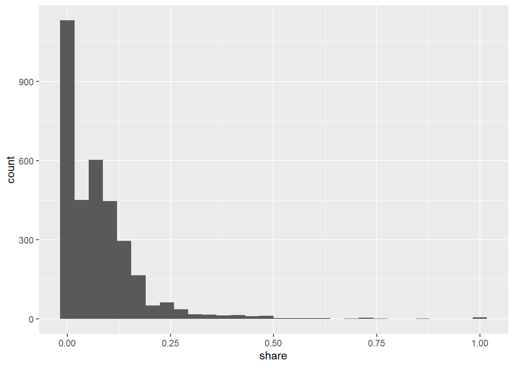

```r
repeats <-
  datasets$wave_10 |> group_by(ID) |>
  summarize(n_seen = n(), n_repeats = sum(shown_both_waves, na.rm = TRUE),
            share = n_repeats/n_seen)


repeats |> ggplot(aes(share)) + geom_histogram()
```

# 3 Paper

Exhibits in manuscript order. Each item has an analysis chunk (estimates) and a formatting chunk (figure/table).

## 3.1 Sample Overview

```r
sample_table <- sample_overview |>
  mutate(wave = if_else(duplicated(wave), "", wave)) |>
  select(
    Wave = wave,
    `Sample stage` = sample_stage,
    Respondents = respondents,
    `Role in analysis` = analysis_role
  )

sample_tex <- knitr::kable(
  sample_table,
  format = "latex",
  booktabs = TRUE,
  linesep = "",
  digits = 0,
  format.args = list(big.mark = ","),
  align = c("l", "l", "r", "l")
)

writeLines(
  sample_tex,
  file.path(tab_dir, "tab_sample_overview.tex")
)

knitr::kable(
  sample_table,
  digits = 0,
  format.args = list(big.mark = ","),
  caption = "Sample construction by study wave"
)
```

Sample construction by study wave

| Wave | Sample stage | Respondents | Role in analysis |
| --- | --- | --- | --- |
| Wave 1 | IDs in raw video source file | 6,694 | Raw source |
|  | SwitchedToRandom = 1 | 4,945 | Attrition baseline |
|  | At least one video with recorded duration | 4,945 | Intermediate sample |
|  | At least two videos started (duration recorded) | 4,436 | Short-term analysis sample |
| Wave 2 | Participated in both waves | 3,634 | Retained respondents |
|  | At least one video with recorded duration | 3,633 | Intermediate sample |
|  | At least two videos started (duration recorded) | 3,359 | Long-term analysis sample |

## 3.2 Fig. 1. Effects of the digital literacy workshop on engagement with TikTok-style videos.

Pooled Wave 1 and Wave 2 ATEs on like, report, share, bookmark, skip, and watch time, by content type. Video FE; SEs clustered by respondent. Super-columns: Engagement (first four) and Attention (skip, watch time). Stem: `fig_1_engagement`.

```r
fig1_outcomes <- c(l_outcomegroups$main, l_outcomegroups[["_other"]])

estimates_fig1 <- bind_rows(
  estimate_pooled_ates(datasets$wave_9, fig1_outcomes) |>
    mutate(horizon = "Wave 1"),
  estimate_pooled_ates(datasets$wave_10, fig1_outcomes) |>
    mutate(horizon = "Wave 2")
)
```

💡 The primary estimand, written out ‘by hand’. Video fixed effects; standard errors clustered by respondent. Wave 1, emotionally manipulative political videos.

```r
feols(videoLikep1r ~ workshop_Treatment | video, cluster = ~ID)
feols(videoCommentTickedp1r ~ workshop_Treatment | video, cluster = ~ID)
feols(videoBookmarkp1r ~ workshop_Treatment | video, cluster = ~ID)
```

```r
# [!] Primary estimand. Video fixed effects; standard errors clustered by respondent.
# Wave 1, emotionally manipulative political videos.
emo_w1 <- datasets$wave_9 |>
  filter(strategy_2 == strategies[1])

like_w1_hand <- feols(
  videoLikep1r ~ workshop_Treatment | video,
  data = emo_w1,
  cluster = ~ID
)
report_w1_hand <- feols(
  videoCommentTickedp1r ~ workshop_Treatment | video,
  data = emo_w1,
  cluster = ~ID
)
bookmark_w1_hand <- feols(
  videoBookmarkp1r ~ workshop_Treatment | video,
  data = emo_w1,
  cluster = ~ID
)

# Same three coefficients from the helper, for a direct check.
helper_check <- estimates_fig1 |>
  filter(horizon == "Wave 1", strategy == strategies[1], outcome %in% c("Like", "Report", "Bookmark")) |>
  select(outcome, estimate)

hand_check <- tibble(
  outcome = c("Like", "Report", "Bookmark"),
  estimate = c(
    coef(like_w1_hand)[["workshop_Treatment"]],
    coef(report_w1_hand)[["workshop_Treatment"]],
    coef(bookmark_w1_hand)[["workshop_Treatment"]]
  )
)
stopifnot(all.equal(
  helper_check |> arrange(outcome) |> pull(estimate),
  hand_check |> arrange(outcome) |> pull(estimate)
))

baseline_w1 <- emo_w1 |>
  filter(workshop_Treatment == 0) |>
  summarise(
    like_baseline = mean(videoLikep1r, na.rm = TRUE),
    report_baseline = mean(videoCommentTickedp1r, na.rm = TRUE),
    bookmark_baseline = mean(videoBookmarkp1r, na.rm = TRUE)
  )
baseline_w1
```

```
# A tibble: 1 × 3
  like_baseline report_baseline bookmark_baseline
          <dbl>           <dbl>             <dbl>
1         0.102          0.0178            0.0243
```

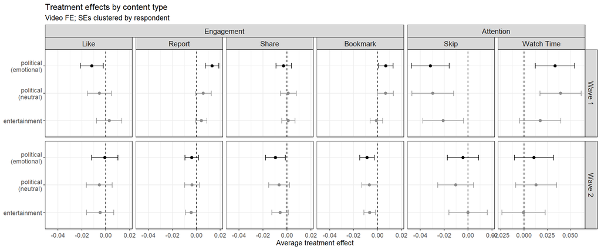

1 Fig. 1. Effects of the digital literacy workshop on engagement with TikTok-style videos.

```r
fig1 <- estimates_fig1 |>
  mutate(
    horizon = factor(horizon, levels = horizon_wave_levels),
    strategy = factor(as.character(strategy), levels = rev(strategy_order_article)),
    outcome = factor(outcome, levels = fig1_outcomes),
    super = outcome_super(outcome),
    strat_color = as.character(strategy)
  ) |>
  ggplot(aes(x = estimate, y = strategy, color = strat_color)) +
  geom_vline(xintercept = 0, linetype = "dashed") +
  geom_errorbar(aes(xmin = conf.low, xmax = conf.high), width = 0.2) +
  geom_point(size = 1.8) +
  facet_nested(horizon ~ super + outcome, scales = "free_x") +
  facetted_pos_scales(x = shared_binary_x_scales(estimates_fig1, fig1_outcomes)) +
  scale_color_manual(values = strategy_color_values, guide = "none") +
  labs(
    x = "Average treatment effect",
    y = NULL,
    title = "Treatment effects by content type",
    subtitle = "Video FE; SEs clustered by respondent"
  ) +
  theme_bw(base_size = 10) +
  theme(
    axis.text.x = element_text(angle = 0, vjust = 0.5, hjust = 0.5, size = 9),
    axis.text.y = element_text(size = 9),
    strip.text = element_text(size = 10),
    panel.spacing.y = unit(6, "pt")
  )

write_fig(
  stem = "fig_1_engagement",
  estimates = estimates_fig1,
  plot = fig1,
  width = 12,
  height = 5,
  dir = fig_dir
)
```

## 3.3 Fig. 2. By party and co-partisanship.

Conditional effects by sending party. Emotionally manipulative political videos, Wave 1. Colors are separate regressions: all respondents, co-partisans (the respondent supports the party that sent the video), and respondents who do not. Super-columns: Engagement (like, report, share, bookmark) and Attention (skip, watch time). Stem: `fig_2_party_partisanship`.

```r
# Demeaned party dummies, video FE, cluster ID.
# Bare treatment = all-parties ATE; party rows recover party-specific TEs.
fit_lin_party_feols <- function(df, outcome_var, party_levels, party_code_map,
                                ref_party = party_levels[length(party_levels)]) {
  interact_parties <- setdiff(party_levels, ref_party)
  df_m <- df |>
    filter(!is.na(.data[[outcome_var]]), !is.na(party), party %in% party_levels) |>
    mutate(party = factor(party, levels = party_levels))

  pi <- setNames(numeric(length(interact_parties)), interact_parties)
  for (p in interact_parties) {
    raw <- as.integer(df_m$party == p)
    pi[p] <- mean(raw, na.rm = TRUE)
    df_m[[paste0("pdm_", party_code_map[[p]])]] <- raw - pi[p]
  }

  pdm_terms <- paste0("pdm_", party_code_map[interact_parties])
  rhs <- paste0("workshop_Treatment * (", paste(pdm_terms, collapse = " + "), ")")
  fit <- feols(
    as.formula(paste(outcome_var, "~", rhs, "| video")),
    data = df_m,
    cluster = ~ID
  )

  b <- coef(fit)
  V <- vcov(fit)
  treat <- "workshop_Treatment"
  lincom <- function(cvec) {
    cvec <- cvec[names(b)]
    cvec[is.na(cvec)] <- 0
    est <- sum(cvec * b)
    se <- sqrt(as.numeric(t(cvec) %*% V %*% cvec))
    tibble(
      estimate = est,
      std.error = se,
      conf.low = est - 1.96 * se,
      conf.high = est + 1.96 * se,
      p.value = 2 * pnorm(-abs(est / se))
    )
  }

  c_ate <- setNames(rep(0, length(b)), names(b))
  c_ate[treat] <- 1
  out_ate <- lincom(c_ate) |> mutate(term = treat, party = "All parties")

  out_parties <- lapply(party_levels, function(p) {
    cvec <- setNames(rep(0, length(b)), names(b))
    cvec[treat] <- 1
    for (j in interact_parties) {
      nm <- paste0(treat, ":pdm_", party_code_map[[j]])
      if (!nm %in% names(b)) next
      cvec[nm] <- if (identical(p, j)) 1 - pi[j] else -pi[j]
    }
    lincom(cvec) |> mutate(term = paste0("TE_", party_code_map[[p]]), party = p)
  }) |> bind_rows()

  bind_rows(out_ate, out_parties) |> mutate(outcome_var = outcome_var)
}

fig2_samples <- list("All" = NULL, "Co-partisan" = 1L, "Not co-partisan" = 0L)
fig2_sample_order <- names(fig2_samples)
fig2_sample_dodge_levels <- rev(fig2_sample_order)
party_labels_az <- sort(names(party_codes))
party_row_levels <- c("All parties", party_labels_az)

fig2_outcomes <- c(l_outcomegroups$main, l_outcomegroups[["_other"]])

df_fig2 <- datasets$wave_9 |>
  filter(strategy_2 == strategies[1], !is.na(party), party %in% names(party_codes))

estimates_fig2 <- lapply(fig2_sample_order, function(samp) {
  df_s <- df_fig2
  if (!is.null(fig2_samples[[samp]])) {
    df_s <- df_s |> filter(partisan == fig2_samples[[samp]])
  }
  lapply(fig2_outcomes, function(Y) {
    fit_lin_party_feols(
      df = df_s,
      outcome_var = v_outcomes[[Y]],
      party_levels = party_labels_az,
      party_code_map = party_codes
    ) |>
      mutate(outcome = Y, sample = samp)
  }) |>
    bind_rows()
}) |>
  bind_rows() |>
  mutate(
    outcome = factor(outcome, levels = fig2_outcomes),
    sample = factor(sample, levels = fig2_sample_dodge_levels),
    party = factor(party, levels = party_row_levels)
  )
```

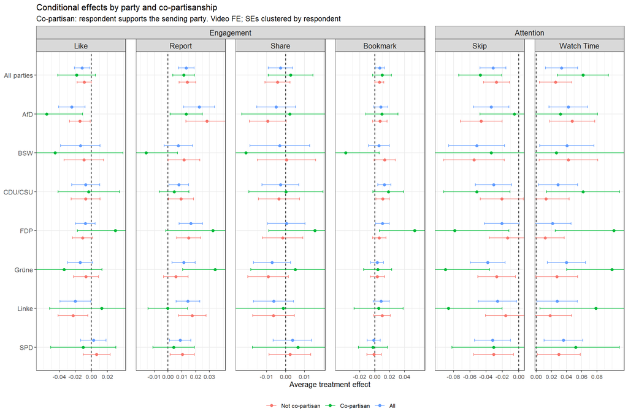

2 Fig. 2. By party and co-partisanship. Co-partisan means the respondent supports the party that sent the video.

```r
dodge_fig2 <- position_dodge(width = 0.55)

# Per-outcome x-limits from point estimates only (not CIs). Buffer is 15% of
# that panel's estimate range, with a 0.005 floor when the range is tiny.
# facetted_pos_scales clips OOB geoms (wide error bars) like coord_cartesian;
# ggh4x ignores per-scale oob, so rows are not dropped.
fig2_x_lims <- estimates_fig2 |>
  summarise(
    lo = min(estimate, na.rm = TRUE),
    hi = max(estimate, na.rm = TRUE),
    .by = outcome
  ) |>
  mutate(
    pad = pmax(0.15 * (hi - lo), 0.005),
    xmin = lo - pad,
    xmax = hi + pad
  )

# Free-x labels are centered on ticks. Ticks near a panel edge spill into the
# next facet (Share's rightmost label ran into Bookmark's leftmost). Keep
# breaks inset from each edge; always retain a zero tick when it is in range.
fig2_x_breaks <- function(lims) {
  candidates <- pretty(lims, n = 5)
  span <- diff(range(lims))
  inset <- 0.14 * span
  inside <- candidates > (lims[1] + inset) & candidates < (lims[2] - inset)
  is_zero <- abs(candidates) < 1e-8 & candidates >= lims[1] & candidates <= lims[2]
  kept <- sort(unique(candidates[inside | is_zero]))
  if (length(kept) < 2) {
    candidates <- pretty(lims, n = 3)
    kept <- sort(unique(candidates[candidates >= lims[1] & candidates <= lims[2]]))
  }
  kept
}

# Unnamed list matches nested columns left-to-right (fig2_outcomes order).
fig2_x_scales <- lapply(fig2_outcomes, function(y) {
  r <- fig2_x_lims[as.character(fig2_x_lims$outcome) == y, ]
  scale_x_continuous(
    limits = c(r$xmin, r$xmax),
    expand = expansion(mult = 0),
    breaks = fig2_x_breaks
  )
})

fig2 <- estimates_fig2 |>
  mutate(
    super = outcome_super(outcome)
  ) |>
  ggplot(aes(x = estimate, y = party, color = sample)) +
  geom_vline(xintercept = 0, linetype = "dashed") +
  geom_errorbar(
    aes(xmin = conf.low, xmax = conf.high),
    width = 0.2,
    position = dodge_fig2
  ) +
  geom_point(size = 1.6, position = dodge_fig2) +
  facet_nested(. ~ super + outcome, scales = "free_x") +
  facetted_pos_scales(x = fig2_x_scales) +
  scale_y_discrete(limits = rev(party_row_levels)) +
  scale_color_discrete(
    limits = fig2_sample_dodge_levels,
    breaks = fig2_sample_order,
    guide = guide_legend(reverse = TRUE)
  ) +
  labs(
    x = "Average treatment effect",
    y = NULL,
    color = NULL,
    title = "Conditional effects by party and co-partisanship",
    subtitle = "Co-partisan: respondent supports the sending party. Video FE; SEs clustered by respondent"
  ) +
  theme_bw(base_size = 10) +
  theme(
    legend.position = "bottom",
    axis.text.x = element_text(angle = 0, vjust = 0.5, hjust = 0.5, size = 8),
    axis.text.y = element_text(size = 9),
    strip.text = element_text(size = 10),
    panel.spacing.x = unit(14, "pt")
  )

write_fig(
  stem = "fig_2_party_partisanship",
  estimates = estimates_fig2,
  plot = fig2,
  width = 12,
  height = 8,
  dir = fig_dir
)
```

We test the joint hypothesis that sender-party treatment-effect contrasts are all zero (no variation across parties) in the overall sample and in the partisan and non-partisan samples.

```r
# Same spec as fit_lin_party_feols: demeaned party dummies, video FE, cluster ID.
# H0: all workshop_Treatment:pdm_* interactions are 0 (effects equal across senders).
wald_party_te_equal <- function(df, outcome_var, party_levels, party_code_map,
                                ref_party = party_levels[length(party_levels)]) {
  interact_parties <- setdiff(party_levels, ref_party)
  df_m <- df |>
    filter(!is.na(.data[[outcome_var]]), !is.na(party), party %in% party_levels) |>
    mutate(party = factor(party, levels = party_levels))

  for (p in interact_parties) {
    raw <- as.integer(df_m$party == p)
    df_m[[paste0("pdm_", party_code_map[[p]])]] <- raw - mean(raw, na.rm = TRUE)
  }

  pdm_terms <- paste0("pdm_", party_code_map[interact_parties])
  rhs <- paste0("workshop_Treatment * (", paste(pdm_terms, collapse = " + "), ")")
  fit <- feols(
    as.formula(paste(outcome_var, "~", rhs, "| video")),
    data = df_m,
    cluster = ~ID
  )

  expected_names <- paste0(
    "workshop_Treatment:pdm_",
    party_code_map[interact_parties]
  )
  interact_names <- grep(
    "^workshop_Treatment:pdm_",
    names(coef(fit)),
    value = TRUE
  )
  stopifnot(setequal(interact_names, expected_names))

  w <- wald(fit, keep = "^workshop_Treatment:pdm_", print = FALSE)
  stat_is_chi2 <- isTRUE(is.na(w$df2)) || is.null(w$df2)
  tibble(
    stat = as.numeric(w$stat),
    stat_name = if (stat_is_chi2) "chi2" else "F",
    df1 = as.integer(w$df1),
    df2 = if (stat_is_chi2) NA_real_ else as.numeric(w$df2),
    p.value = as.numeric(w$p),
    n_terms = length(interact_names),
    terms = paste(interact_names, collapse = ", ")
  )
}

fig2_party_wald <- lapply(fig2_sample_order, function(samp) {
  df_s <- df_fig2
  if (!is.null(fig2_samples[[samp]])) {
    df_s <- df_s |> filter(partisan == fig2_samples[[samp]])
  }
  lapply(fig2_outcomes, function(Y) {
    wald_party_te_equal(
      df = df_s,
      outcome_var = v_outcomes[[Y]],
      party_levels = party_labels_az,
      party_code_map = party_codes
    ) |>
      mutate(outcome = Y, sample = samp)
  }) |>
    bind_rows()
}) |>
  bind_rows() |>
  mutate(
    outcome = factor(outcome, levels = fig2_outcomes),
    sample = factor(sample, levels = fig2_sample_order)
  )

stopifnot(!anyNA(fig2_party_wald$p.value), !anyNA(fig2_party_wald$stat))
stopifnot(all(fig2_party_wald$n_terms > 0L))

# Raw inspection: All sample, Like — joint test that party × treatment contrasts are 0
df_like <- df_fig2 |>
  filter(!is.na(videoLikep1r), !is.na(party), party %in% party_labels_az)
df_like$pdm_afd    <- as.integer(df_like$party == "AfD")     - mean(df_like$party == "AfD")
df_like$pdm_bsw    <- as.integer(df_like$party == "BSW")     - mean(df_like$party == "BSW")
df_like$pdm_cdu    <- as.integer(df_like$party == "CDU/CSU") - mean(df_like$party == "CDU/CSU")
df_like$pdm_fdp    <- as.integer(df_like$party == "FDP")     - mean(df_like$party == "FDP")
df_like$pdm_gruene <- as.integer(df_like$party == "Grüne")   - mean(df_like$party == "Grüne")
df_like$pdm_linke  <- as.integer(df_like$party == "Linke")   - mean(df_like$party == "Linke")
```

💡 Wald test, written out.

```r
like_party_hand <- feols(
  videoLikep1r ~ workshop_Treatment * (pdm_afd + pdm_bsw + pdm_cdu +
    pdm_fdp + pdm_gruene + pdm_linke) | video,
  data = df_like,
  cluster = ~ID
)
wald(
  like_party_hand,
  c(
    "workshop_Treatment:pdm_afd", "workshop_Treatment:pdm_bsw", "workshop_Treatment:pdm_cdu",
    "workshop_Treatment:pdm_fdp", "workshop_Treatment:pdm_gruene", "workshop_Treatment:pdm_linke"
  )
)
```

```
Wald test, H0: joint nullity of workshop_Treatment:pdm_afd, workshop_Treatment:pdm_bsw, workshop_Treatment:pdm_cdu, workshop_Treatment:pdm_fdp, workshop_Treatment:pdm_gruene and workshop_Treatment:pdm_linke
 stat = 1.65851, p-value = 0.127017, on 6 and 4,399 DoF, VCOV: Clustered (ID).
```

💡 AfD liking in the all-respondent regression. Reference party is SPD. For interacted party j, the weight on the treatment interaction is (1 - pi_j) for AfD and -pi_j for every other party.

```r
feols(
  videoLikep1r ~ workshop_Treatment * (pdm_afd + pdm_bsw + pdm_cdu +
    pdm_fdp + pdm_gruene + pdm_linke) | video,
  cluster = ~ID
)
```

```r
# [!] AfD liking effect in the all-respondent regression above.
# Reference party is SPD. For interacted party j, the weight on
# workshop:pdm_j is (1 - pi_j) for AfD and -pi_j for every other party.
b_like <- coef(like_party_hand)
pi_party <- c(
  afd = mean(df_like$party == "AfD"),
  bsw = mean(df_like$party == "BSW"),
  cdu = mean(df_like$party == "CDU/CSU"),
  fdp = mean(df_like$party == "FDP"),
  gruene = mean(df_like$party == "Grüne"),
  linke = mean(df_like$party == "Linke")
)
c_afd <- c(
  "workshop_Treatment" = 1,
  "workshop_Treatment:pdm_afd" = unname(1 - pi_party["afd"]),
  "workshop_Treatment:pdm_bsw" = unname(-pi_party["bsw"]),
  "workshop_Treatment:pdm_cdu" = unname(-pi_party["cdu"]),
  "workshop_Treatment:pdm_fdp" = unname(-pi_party["fdp"]),
  "workshop_Treatment:pdm_gruene" = unname(-pi_party["gruene"]),
  "workshop_Treatment:pdm_linke" = unname(-pi_party["linke"])
)
afd_like_hand <- sum(c_afd * b_like[names(c_afd)])
afd_like_helper <- estimates_fig2 |>
  filter(outcome == "Like", sample == "All", party == "AfD") |>
  pull(estimate)
stopifnot(abs(afd_like_hand - afd_like_helper) < 1e-8)
c(afd_like = afd_like_hand)
```

```
   afd_like
-0.02453281
```

All tests:

```r
fmt_p <- function(p) {
  ifelse(p < 0.001, "<0.001", sprintf("%.3f", p))
}

df2_note <- fig2_party_wald |>
  summarise(df2 = unique(df2), .by = sample) |>
  mutate(txt = paste0(sample, " ", round(df2))) |>
  pull(txt) |>
  paste(collapse = "; ")

fig2_wald_table <- fig2_party_wald |>
  mutate(
    F = sprintf("%.2f", stat),
    p = fmt_p(p.value)
  ) |>
  select(outcome, sample, F, p) |>
  tidyr::pivot_wider(
    names_from = sample,
    values_from = c(F, p),
    names_glue = "{sample} {.value}"
  ) |>
  select(
    Outcome = outcome,
    `All F`, `All p`,
    `Co-partisan F`, `Co-partisan p`,
    `Not co-partisan F`, `Not co-partisan p`
  )

knitr::kable(
  fig2_wald_table,
  align = c("l", rep("r", 6)),
  caption = paste0(
    "Joint cluster-robust Wald tests that party × treatment interactions ",
    "are zero (Fig. 2 specification; video FE, SEs clustered by respondent). ",
    "H0: workshop_Treatment:pdm_afd = pdm_bsw = pdm_cdu = pdm_fdp = ",
    "pdm_gruene = pdm_linke = 0 (SPD omitted). F(6, df2) with df2: ",
    df2_note, "."
  )
)
```

Joint cluster-robust Wald tests that party × treatment interactions are zero (Fig. 2 specification; video FE, SEs clustered by respondent). H0: workshop_Treatment:pdm_afd = pdm_bsw = pdm_cdu = pdm_fdp = pdm_gruene = pdm_linke = 0 (SPD omitted). F(6, df2) with df2: All 4399; Co-partisan 3332; Not co-partisan 4247.

| Outcome | All F | All p | Co-partisan F | Co-partisan p | Not co-partisan F | Not co-partisan p |
| --- | --- | --- | --- | --- | --- | --- |
| Like | 1.66 | 0.127 | 1.66 | 0.128 | 1.33 | 0.240 |
| Report | 2.04 | 0.057 | 2.64 | 0.015 | 1.77 | 0.101 |
| Share | 0.90 | 0.492 | 0.35 | 0.913 | 0.95 | 0.457 |
| Bookmark | 1.55 | 0.158 | 1.83 | 0.089 | 1.03 | 0.407 |
| Skip | 0.75 | 0.611 | 1.64 | 0.133 | 1.56 | 0.156 |
| Watch Time | 0.96 | 0.453 | 0.96 | 0.454 | 1.54 | 0.162 |

# 4 Supporting Information

Exhibits in compiled SI order. HTML figure labels start at **Fig. S2** (Fig. S1 is the static example-video PNG). Not created here: Table S2 (scraped-handle longtable), Fig. S1 (example-video PNG), workshop/interface screenshots, and Table S15 (PAP reconciliation, written in the SI `.tex`).

## 4.1 Table S1. Descriptives on videos and video behavior

```r
summarise_video_wave <- function(df, horizon) {
  df |>
    summarise(
      respondents = n_distinct(ID, na.rm = TRUE),
      video_observations = n(),
      videos_per_respondent = video_observations / respondents,
      like = mean(videoLikep1r, na.rm = TRUE),
      share = mean(videoSharep1r, na.rm = TRUE),
      bookmark = mean(videoBookmarkp1r, na.rm = TRUE),
      report = mean(videoCommentTickedp1r, na.rm = TRUE)
    ) |>
    mutate(horizon = horizon, .before = 1)
}



video_summary <- function(d) {
  tibble(
    Statistic = c(
      "Overview",
      "Respondents",
      "Number of videos per respondent",
      "Watched videos",
      "Political -- Anger",
      "Political -- Fear",
      "Political -- Superiority",
      "Political -- Neutral",
      "Entertainment",
      "Video behavior",
      "Like",
      "Share",
      "Bookmark",
      "Report"
    ),

    value = c(
      "",
      comma(n_distinct(d$ID)),
      number(nrow(d) / n_distinct(d$ID), accuracy = 0.01),
      comma(nrow(d)),
      comma(sum(d$content == "political" &
                  d$strategy == "anger", na.rm = TRUE)),
      comma(sum(d$content == "political" &
                  d$strategy == "fear", na.rm = TRUE)),
      comma(sum(d$content == "political" &
                  d$strategy == "superiority", na.rm = TRUE)),
      comma(sum(d$content == "political" &
                  d$strategy == "neutral", na.rm = TRUE)),
      comma(sum(d$content == "entertainment", na.rm = TRUE)),
      "",
      comma(sum(d$videoLikep1r == 1, na.rm = TRUE)),
      comma(sum(d$videoSharep1r == 1, na.rm = TRUE)),
      comma(sum(d$videoBookmarkp1r == 1, na.rm = TRUE)),
      comma(sum(d$videoCommentTickedp1r == 1, na.rm = TRUE))
    )
  )
}

tab_s1 <- bind_rows(
  `Short-term` = video_summary(datasets$wave_9),
  `Long-term`  = video_summary(datasets$wave_10),
  .id = "period"
) |>
  pivot_wider(
    names_from = period,
    values_from = value
  ) |>
  mutate(
    blank_left = "",
    blank_right = ""
  ) |>
  select(
    blank_left,
    Statistic,
    `Short-term`,
    `Long-term`,
    blank_right
  )

s1_tex_label <- c(
  "Overview" = "\\textbf{Overview}",
  "Respondents" = "\\hspace{0.3cm} Respondents",
  "Number of videos per respondent" = "\\hspace{0.3cm} Number of videos per respondent",
  "Watched videos" = "\\hspace{0.3cm} Watched videos",
  "Political -- Anger" = "\\hspace{0.8cm} Political -- Anger",
  "Political -- Fear" = "\\hspace{0.8cm} Political -- Fear",
  "Political -- Superiority" = "\\hspace{0.8cm} Political -- Superiority",
  "Political -- Neutral" = "\\hspace{0.8cm} Political -- Neutral",
  "Entertainment" = "\\hspace{0.8cm} Entertainment",
  "Video behavior" = "\\textbf{Video behavior}",
  "Like" = "\\hspace{0.3cm} Like",
  "Share" = "\\hspace{0.3cm} Share",
  "Bookmark" = "\\hspace{0.3cm} Bookmark",
  "Report" = "\\hspace{0.3cm} Report"
)
tab_s1 |>
  mutate(Statistic = unname(s1_tex_label[Statistic])) |>
  knitr::kable(
    format = "latex",
    booktabs = TRUE,
    linesep = "",
    escape = FALSE,
    col.names = c(
      "",
      "",
      "\\mc{\\textbf{Short-term}}",
      "\\mc{\\textbf{Long-term}}",
      ""
    ),
    align = c(
      "p{0.5cm}",
      "p{6.5cm}",
      "r",
      "r",
      "p{0.5cm}"
    )
  ) |>
  writeLines(
    file.path(
      tab_dir,
      "tab_s1_video_descriptives.tex"
    )
  )

knitr::kable(
  tab_s1 |>
    transmute(
      Statistic = ifelse(
        Statistic %in% c("Overview", "Video behavior"),
        paste0("<b>", Statistic, "</b>"),
        Statistic
      ),
      `Short-term`,
      `Long-term`
    ),
  format = "html",
  escape = FALSE,
  caption = "Table S1. Descriptives on videos and video behavior"
)
```

Table S1. Descriptives on videos and video behavior

| Statistic | Short-term | Long-term |
| --- | --- | --- |
| **Overview** |  |  |
| Respondents | 4,436 | 3,359 |
| Number of videos per respondent | 29.97 | 36.28 |
| Watched videos | 132,954 | 121,880 |
| Political -- Anger | 18,235 | 16,753 |
| Political -- Fear | 14,982 | 13,776 |
| Political -- Superiority | 18,773 | 17,199 |
| Political -- Neutral | 20,884 | 19,243 |
| Entertainment | 60,080 | 54,909 |
| **Video behavior** |  |  |
| Like | 12,446 | 10,613 |
| Share | 4,209 | 4,241 |
| Bookmark | 3,032 | 2,427 |
| Report | 2,364 | 1,849 |

## 4.2 Table S3. Average Cohen’s Kappa between coder pairings

Mean pairwise Cohen’s $\kappa$ across three coder rounds (anger, fear, superiority, and any-emotion vs none). Same statistic as `pre_survey_prep/3.3_Validted Political Set.ipynb`. Recomputed if `data/coder_ratings.rds` is present (wide panel with `anger_1`/`anger_2`/`anger_3`, and the same for fear and superiority); otherwise the published means from that notebook are written so this file still produces the SI `.tex`.

```r
cohen_kappa <- function(x, y) {
  ok <- stats::complete.cases(x, y)
  x <- as.integer(x[ok])
  y <- as.integer(y[ok])
  if (length(x) < 2L) return(NA_real_)
  p0 <- mean(x == y)
  px <- c(mean(x == 0), mean(x == 1))
  py <- c(mean(y == 0), mean(y == 1))
  pe <- sum(px * py)
  if (abs(1 - pe) < 1e-12) return(NA_real_)
  unname((p0 - pe) / (1 - pe))
}
mean_pairwise_kappa <- function(c1, c2, c3) {
  mean(c(cohen_kappa(c1, c2), cohen_kappa(c1, c3), cohen_kappa(c2, c3)), na.rm = TRUE)
}

kappa_src <- "pre_survey_prep/3.3_Validted Political Set.ipynb (published means)"
kappa_s3 <- c(
  anger = 0.492,
  fear = 0.453,
  superiority = 0.371,
  any_emotion = 0.404
)

if (!is.null(coder_ratings)) {
  cr <- coder_ratings
  need <- c(
    "anger_1", "anger_2", "anger_3",
    "fear_1", "fear_2", "fear_3",
    "superiority_1", "superiority_2", "superiority_3"
  )
  stopifnot(all(need %in% names(cr)))
  any_em <- function(a, f, s) {
    ifelse(
      a == 1 | f == 1 | s == 1,
      1L,
      ifelse(a == 0 & f == 0 & s == 0, 0L, NA_integer_)
    )
  }
  kappa_s3 <- c(
    anger = mean_pairwise_kappa(cr$anger_1, cr$anger_2, cr$anger_3),
    fear = mean_pairwise_kappa(cr$fear_1, cr$fear_2, cr$fear_3),
    superiority = mean_pairwise_kappa(
      cr$superiority_1, cr$superiority_2, cr$superiority_3
    ),
    any_emotion = mean_pairwise_kappa(
      any_em(cr$anger_1, cr$fear_1, cr$superiority_1),
      any_em(cr$anger_2, cr$fear_2, cr$superiority_2),
      any_em(cr$anger_3, cr$fear_3, cr$superiority_3)
    )
  )
  kappa_src <- "data/coder_ratings.rds"
}
cat("Table S3 kappas from ", kappa_src, "\n", sep = "")
```

```
Table S3 kappas from pre_survey_prep/3.3_Validted Political Set.ipynb (published means)
```

```r
print(round(kappa_s3, 3))
```

```
      anger        fear superiority any_emotion
      0.492       0.453       0.371       0.404
```

```r
tex_s3 <- c(
  "\\begin{table}[ht]",
  "    \\centering",
  "\\begin{tabular}{|r|r|r|r|}",
  "\\hline",
  "\\textbf{Anger} & \\textbf{Fear} & \\textbf{Superiority} & \\textbf{Any emotion} \\\\",
  "\\hline",
  sprintf(
    "%.3f & %.3f & %.3f & %.3f \\\\",
    kappa_s3[["anger"]],
    kappa_s3[["fear"]],
    kappa_s3[["superiority"]],
    kappa_s3[["any_emotion"]]
  ),
  "\\hline",
  "\\end{tabular}",
  "    \\caption{Average Cohen's Kappa between coder pairings}",
  "    \\label{tab:cohens_kappa}",
  "\\end{table}"
)
writeLines(tex_s3, file.path(tab_dir, "tab_s3_cohens_kappa.tex"))
knitr::kable(
  tibble(
    Anger = round(kappa_s3[["anger"]], 3),
    Fear = round(kappa_s3[["fear"]], 3),
    Superiority = round(kappa_s3[["superiority"]], 3),
    `Any emotion` = round(kappa_s3[["any_emotion"]], 3)
  ),
  caption = "Table S3. Average Cohen's Kappa between coder pairings"
)
```

Table S3. Average Cohen’s Kappa between coder pairings

| Anger | Fear | Superiority | Any emotion |
| --- | --- | --- | --- |
| 0.492 | 0.453 | 0.371 | 0.404 |

## 4.3 Table S4. Distribution of emotion categories in the full political sample and survey video bundle

Compiled SI Table S4 is `tab_s4_strategy_by_party_combined` (static TeX fragment). This chunk writes experiment-sample party × strategy counts (`tab_s4_strategy_by_party`). Party × `strategy_2` counts for the 400 experiment videos (unique `video` in Wave 1). Entertainment videos have blank party and form their own row; political videos are emotional or neutral.

```r
party_levels_s4 <- c("AfD", "BSW", "CDU/CSU", "FDP", "Grüne", "Linke", "SPD")

s4_vids <- datasets$wave_9 |>
  distinct(video, .keep_all = TRUE) |>
  mutate(
    row_lab = ifelse(strategy_2 == "entertainment", "Entertainment", as.character(party)),
    col_lab = case_when(
      strategy_2 == strategies[1] ~ "emotional",
      strategy_2 == strategies[2] ~ "neutral",
      strategy_2 == "entertainment" ~ "entertainment"
    )
  )
stopifnot(nrow(s4_vids) == 400L)

s4_tab <- as.data.frame.matrix(with(s4_vids, table(row_lab, col_lab))) |>
  tibble::rownames_to_column("row_lab") |>
  transmute(
    row_lab = factor(row_lab, levels = c(party_levels_s4, "Entertainment")),
    emotional,
    neutral,
    entertainment,
    all = emotional + neutral + entertainment
  ) |>
  arrange(row_lab)
s4_tab <- bind_rows(
  s4_tab,
  summarise(s4_tab, row_lab = "Total", across(-row_lab, sum))
)
```

```r
fmt_s4 <- function(r) {
  sprintf(
    "%s & %s & %s & %s & %s \\\\",
    r$row_lab, r$emotional, r$neutral, r$entertainment, r$all
  )
}
body <- vapply(seq_len(nrow(s4_tab)), function(i) {
  paste0(fmt_s4(s4_tab[i, ]), " \\hline")
}, character(1))
tex_s4 <- c(
  "\\begin{table}[ht]",
  "\\centering",
  "\\begin{tabular}{|l|l|l|l|l|}",
  "\\hline",
  " & \\textbf{Emotional political} & \\textbf{Neutral political} & \\textbf{Entertainment} & \\textbf{All} \\\\ \\hline",
  body,
  "\\end{tabular}",
  "\\caption{Strategy distribution across videos}",
  "\\label{tiktok:strategy}",
  "\\end{table}"
)
writeLines(tex_s4, file.path(tab_dir, "tab_s4_strategy_by_party.tex"))
knitr::kable(
  s4_tab |>
    select(
      Party = row_lab,
      `Emotional political` = emotional,
      `Neutral political` = neutral,
      Entertainment = entertainment,
      All = all
    ),
  caption = "Table S4. Strategy distribution across videos (experiment sample; compiled SI Table S4 uses the combined fragment)"
)
```

Table S4. Strategy distribution across videos (experiment sample; compiled SI Table S4 uses the combined fragment)

| Party | Emotional political | Neutral political | Entertainment | All |
| --- | --- | --- | --- | --- |
| AfD | 27 | 9 | 0 | 36 |
| BSW | 7 | 9 | 0 | 16 |
| CDU/CSU | 27 | 9 | 0 | 36 |
| FDP | 23 | 9 | 0 | 32 |
| Grüne | 25 | 9 | 0 | 34 |
| Linke | 20 | 9 | 0 | 29 |
| SPD | 27 | 9 | 0 | 36 |
| Entertainment | 0 | 0 | 181 | 181 |
| Total | 156 | 63 | 181 | 400 |

## 4.4 Fig. S2. Engagement with the platform.

Stem: `fig_s2_platform_comments`. Comment classification of open-ended platform remarks (ecological validity).

```r
levels_vec <- c(
  "0 = setup skepticism",
  "1 = platform-focused",
  "2 = content-focused",
  "3 = other/unclear"
)
comments_counts <- comments_df |>
  mutate(
    scale_label = fct_explicit_na(scale_label, na_level = "NA"),
    scale_label = fct_relevel(scale_label, levels_vec, after = 0)
  ) |>
  count(scale_label, name = "n") |>
  mutate(pct = n / sum(n))
```

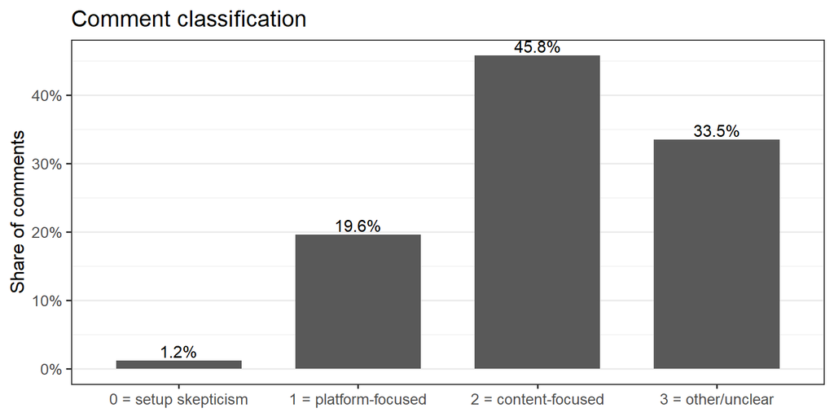

3 Fig. S2. Engagement with the platform.

```r
fig_s2 <- comments_counts |>
  ggplot(aes(x = scale_label, y = pct)) +
  geom_col(width = 0.7) +
  geom_text(aes(label = percent(pct, accuracy = 0.1)), vjust = -0.25, size = 4) +
  scale_y_continuous(labels = percent_format(accuracy = 1)) +
  labs(x = NULL, y = "Share of comments", title = "Comment classification") +
  theme_bw(base_size = 13) +
  theme(panel.grid.major.x = element_blank())

write_fig(
  stem = "fig_s2_platform_comments",
  estimates = comments_counts,
  plot = fig_s2,
  width = 8,
  height = 4,
  dir = si_fig_dir
)
```

## 4.5 Fig. S3. Levels of outcomes by treatment condition.

Stem: `fig_s3_outcome_levels_treat_control`. Table-order companion to manuscript Figure 1: mean Wave 1 and Wave 2 outcome levels by content type and treatment (not ATEs). Same 2×6 layout; all three content types; cluster-robust 95% CIs by respondent. Super-columns: Engagement (first four) and Attention (skip, watch time). Each outcome column has its own x-scale.

```r
treat_cols <- c(Control = "#4C78A8", Treatment = "#E45756")
outcome_order_levels <- c(l_outcomegroups$main, l_outcomegroups[["_other"]])

df_levels_row <- bind_rows(
  datasets$wave_9 |> mutate(horizon = "Wave 1"),
  datasets$wave_10 |> mutate(horizon = "Wave 2")
) |>
  transmute(
    ID = as.character(ID),
    horizon = factor(horizon, levels = horizon_wave_levels),
    strategy = factor(as.character(strategy_2), levels = rev(strategy_order_article)),
    treatment = factor(
      ifelse(workshop_Treatment == 1, "Treatment", "Control"),
      levels = c("Control", "Treatment")
    ),
    Like = as.numeric(videoLikep1r),
    Report = as.numeric(videoCommentTickedp1r),
    Share = as.numeric(videoSharep1r),
    Bookmark = as.numeric(videoBookmarkp1r),
    Skip = as.numeric(skipped_video_),
    `Watch Time` = as.numeric(watch_percentage_)
  ) |>
  pivot_longer(
    cols = all_of(outcome_order_levels),
    names_to = "outcome",
    values_to = "y"
  ) |>
  filter(is.finite(y), !is.na(strategy), !is.na(treatment))

est_levels <- df_levels_row |>
  mutate(outcome = factor(outcome, levels = outcome_order_levels)) |>
  group_by(horizon, outcome, strategy, treatment) |>
  group_modify(~ {
    m <- estimatr::lm_robust(y ~ 1, data = .x, clusters = ID)
    broom::tidy(m, conf.int = TRUE) |>
      dplyr::filter(term == "(Intercept)") |>
      dplyr::transmute(
        estimate,
        std.error,
        conf.low,
        conf.high,
        n = nrow(.x),
        n_id = dplyr::n_distinct(.x$ID)
      )
  }) |>
  ungroup()
```

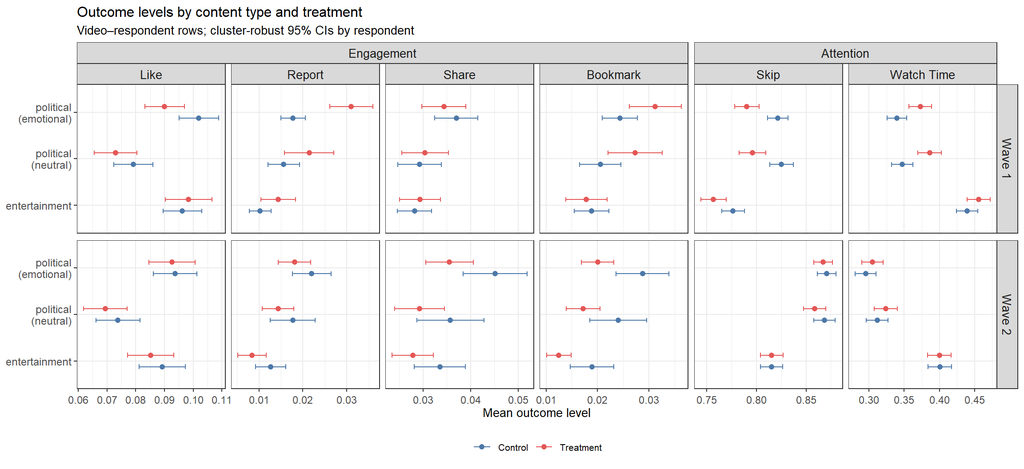

4 Fig. S3. Levels of outcomes by treatment condition.

```r
pd <- position_dodge(width = 0.5)

fig_s3_outcome_levels_treat_control <- est_levels |>
  mutate(super = outcome_super(outcome)) |>
  ggplot(aes(x = estimate, y = strategy, color = treatment)) +
  geom_errorbar(
    aes(xmin = conf.low, xmax = conf.high),
    width = 0.2,
    position = pd
  ) +
  geom_point(size = 1.8, position = pd) +
  facet_nested(horizon ~ super + outcome, scales = "free_x") +
  scale_color_manual(values = treat_cols, name = NULL) +
  labs(
    x = "Mean outcome level",
    y = NULL,
    title = "Outcome levels by content type and treatment",
    subtitle = "Video–respondent rows; cluster-robust 95% CIs by respondent"
  ) +
  theme_bw(base_size = 10) +
  theme(
    axis.text.x = element_text(angle = 0, vjust = 0.5, hjust = 0.5, size = 9),
    axis.text.y = element_text(size = 9),
    strip.text = element_text(size = 10),
    panel.spacing.y = unit(6, "pt"),
    legend.position = "bottom"
  )

write_fig(
  stem = "fig_s3_outcome_levels_treat_control",
  estimates = est_levels,
  plot = fig_s3_outcome_levels_treat_control,
  width = 12,
  height = 5.5,
  dir = si_fig_dir
)
```

## 4.6 Fig. S4. Patterns conditional on strategy.

Stem: `fig_s4_by_strategy`. Wave 1 ATEs by emotional strategy (anger, fear, superiority) on like, report, share, bookmark, skip, and watch time. Video FE; SEs clustered by respondent. Super-columns: Engagement (first four) and Attention (skip, watch time).

```r
s3_outcomes <- c(l_outcomegroups$main, l_outcomegroups[["_other"]])
emotion_strats <- c("anger", "fear", "superiority")

estimates_s3 <- lapply(s3_outcomes, function(Y) {
  lapply(emotion_strats, function(S) {
    run_feols_tidy(
      df = datasets$wave_9 |> filter(strategy == S),
      outcome_var = v_outcomes[[Y]],
      extra_cols = list(outcome = Y, strategy = S)
    )
  }) |> bind_rows()
}) |>
  bind_rows() |>
  mutate(outcome = factor(outcome, levels = s3_outcomes))
```

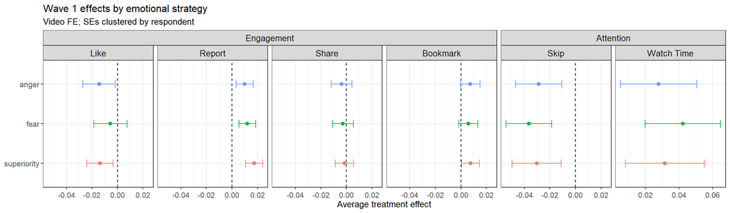

5 Fig. S4. Patterns conditional on strategy.

```r
fig_s3 <- estimates_s3 |>
  mutate(
    strategy = factor(as.character(strategy), levels = rev(emotion_strats)),
    outcome = factor(outcome, levels = s3_outcomes),
    super = outcome_super(outcome)
  ) |>
  ggplot(aes(x = estimate, y = strategy, color = strategy)) +
  geom_vline(xintercept = 0, linetype = "dashed") +
  geom_errorbar(aes(xmin = conf.low, xmax = conf.high), width = 0.2) +
  geom_point(size = 1.8) +
  facet_nested(. ~ super + outcome, scales = "free_x") +
  facetted_pos_scales(x = shared_binary_x_scales(estimates_s3, s3_outcomes)) +
  scale_color_discrete(guide = "none") +
  labs(
    x = "Average treatment effect",
    y = NULL,
    title = "Wave 1 effects by emotional strategy",
    subtitle = "Video FE; SEs clustered by respondent"
  ) +
  theme_bw(base_size = 10) +
  theme(
    axis.text.x = element_text(angle = 0, vjust = 0.5, hjust = 0.5, size = 9),
    axis.text.y = element_text(size = 9),
    strip.text = element_text(size = 10)
  )

write_fig(
  stem = "fig_s4_by_strategy",
  estimates = estimates_s3,
  plot = fig_s3,
  width = 12,
  height = 3.5,
  dir = si_fig_dir
)
```

## 4.7 Fig. S5. Differential effects for emotional political videos.

Stem: `fig_s5_type_treat_did`. Treatment × type interactions on all six outcomes (emotional vs politically neutral; emotional vs entertainment). Pairwise samples; video FE; cluster-robust 95% CIs by respondent. Companion to Tables S5–S8. Super-columns: Engagement (first four) and Attention (skip, watch time).

```r
outcome_order_did <- c(l_outcomegroups$main, l_outcomegroups[["_other"]])

contrast_specs <- list(
  "Emotional vs neutral\n× treatment" = strategies,
  "Emotional vs entertainment\n× treatment" = c(strategies[1], "entertainment")
)
horizon_data <- list(
  "Wave 1" = datasets$wave_9,
  "Wave 2" = datasets$wave_10
)

est_did <- bind_rows(lapply(names(horizon_data), function(h) {
  bind_rows(lapply(names(contrast_specs), function(c_lab) {
    df <- horizon_data[[h]] |>
      filter(strategy_2 %in% contrast_specs[[c_lab]]) |>
      mutate(
        type_dummy = as.integer(strategy_2 == strategies[1]),
        across(all_of(unname(v_outcomes)), \(z) as.numeric(haven::zap_labels(z)))
      )
    bind_rows(lapply(outcome_order_did, function(Y) {
      feols(
        as.formula(paste0(v_outcomes[[Y]], " ~ workshop_Treatment * type_dummy | video")),
        data = df,
        cluster = ~ID
      ) |>
        broom::tidy(conf.int = TRUE) |>
        filter(term == "workshop_Treatment:type_dummy") |>
        mutate(horizon = h, contrast = c_lab, outcome = Y)
    }))
  }))
}))
```

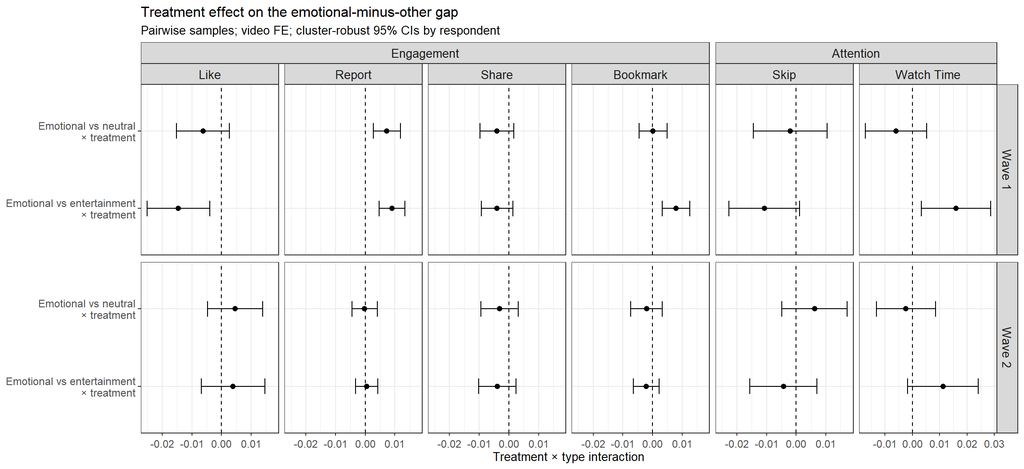

6 Fig. S5. Differential effects for emotional political videos.

```r
fig_s4_type_treat_did <- est_did |>
  mutate(
    horizon = factor(horizon, levels = horizon_wave_levels),
    outcome = factor(outcome, levels = outcome_order_did),
    contrast = factor(contrast, levels = rev(names(contrast_specs))),
    super = outcome_super(outcome)
  ) |>
  ggplot(aes(x = estimate, y = contrast)) +
  geom_vline(xintercept = 0, linetype = "dashed") +
  geom_errorbar(aes(xmin = conf.low, xmax = conf.high), width = 0.2) +
  geom_point(size = 1.8) +
  facet_nested(horizon ~ super + outcome, scales = "free_x") +
  facetted_pos_scales(x = shared_binary_x_scales(est_did, outcome_order_did)) +
  labs(
    x = "Treatment × type interaction",
    y = NULL,
    title = "Treatment effect on the emotional-minus-other gap",
    subtitle = "Pairwise samples; video FE; cluster-robust 95% CIs by respondent"
  ) +
  theme_bw(base_size = 10) +
  theme(
    axis.text.x = element_text(angle = 0, vjust = 0.5, hjust = 0.5, size = 9),
    axis.text.y = element_text(size = 9),
    strip.text = element_text(size = 10),
    panel.spacing.y = unit(6, "pt")
  )

write_fig(
  stem = "fig_s5_type_treat_did",
  estimates = est_did,
  plot = fig_s4_type_treat_did,
  width = 12,
  height = 5.5,
  dir = si_fig_dir
)
```

## 4.8 Tables S5–S8. Emotional vs other content-type contrasts

Wave 1 like and report: emotional vs politically neutral (Tables S5–S6) and emotional vs entertainment (Tables S7–S8). Video FE; cluster ID. Columns: ALL and sending parties.

```r
compare_outcomes <- c("Like", "Report")
compare_group_names <- c("ALL", names(party_codes))

fit_type_contrast <- function(df, outcome_name, type_var) {
  y <- v_outcomes[[outcome_name]]
  feols(
    as.formula(paste0(y, " ~ workshop_Treatment * ", type_var, " | video")),
    data = df,
    cluster = ~ID
  )
}

type_contrast_coef_map <- list(
  "workshop_Treatment" = "Treatment (comparison type)",
  "workshop_Treatment:emotional" = "Treatment × type"
)

df_pol <- datasets$wave_9 |>
  filter(strategy_2 %in% strategies) |>
  mutate(emotional = as.integer(strategy_2 == strategies[1]))

models_emo_neu <- lapply(compare_outcomes, function(Y) {
  fits <- c(
    list(ALL = fit_type_contrast(df_pol, Y, "emotional")),
    lapply(names(party_codes), function(P) {
      fit_type_contrast(df_pol |> filter(party == P), Y, "emotional")
    }) |> setNames(names(party_codes))
  )
  fits[compare_group_names]
}) |>
  setNames(compare_outcomes)

df_ee <- datasets$wave_9 |>
  filter(strategy_2 %in% c(strategies[1], "entertainment")) |>
  mutate(emotional = as.integer(strategy_2 == strategies[1]))

models_emo_ent <- lapply(compare_outcomes, function(Y) {
  fits <- c(
    list(ALL = fit_type_contrast(df_ee, Y, "emotional")),
    lapply(names(party_codes), function(P) {
      df_p <- df_ee |> filter(party == P | strategy_2 == "entertainment")
      fit_type_contrast(df_p, Y, "emotional")
    }) |> setNames(names(party_codes))
  )
  fits[compare_group_names]
}) |>
  setNames(compare_outcomes)
```

```r
write_type_contrast <- function(models, dest_stem, caption, label, html_caption = caption) {
  write_tab_rds(models, dest_stem)
  texreg::texreg(
    models,
    file = file.path(tab_dir, paste0(dest_stem, ".tex")),
    digits = 3,
    include.ci = FALSE,
    custom.model.names = names(models),
    custom.coef.map = type_contrast_coef_map,
    caption = caption,
    label = label,
    stars = texreg_stars
  )
  texreg::htmlreg(
    models,
    digits = 3,
    include.ci = FALSE,
    custom.model.names = names(models),
    custom.coef.map = type_contrast_coef_map,
    caption = html_caption,
    stars = texreg_stars
  )
}

write_type_contrast(
  models_emo_neu$Like,
  "tab_s5_emo_vs_neutral_like",
  "Emotional vs politically neutral: Like (Wave 1). Video FE; SEs clustered by respondent.",
  "tab:compare_emotional_vs_neutral_like",
  "Table S5. Emotional vs politically neutral: Like (Wave 1). Video FE; SEs clustered by respondent."
)
```

```
The table was written to the file 'sn-tables/tab_s5_emo_vs_neutral_like.tex'.
```

Table S5. Emotional vs politically neutral: Like (Wave 1). Video FE; SEs clustered by respondent.

|  | ALL | AfD | CDU/CSU | Linke | SPD | Grüne | FDP | BSW |
| --- | --- | --- | --- | --- | --- | --- | --- | --- |
| Treatment (comparison type) | -0.005 | -0.019* | -0.000 | -0.021* | 0.015 | 0.016 | -0.013 | -0.014 |
|  | (0.005) | (0.011) | (0.009) | (0.012) | (0.010) | (0.011) | (0.008) | (0.011) |
| Treatment × type | -0.006 | -0.006 | -0.007 | 0.001 | -0.013 | -0.030*** | 0.006 | -0.000 |
|  | (0.005) | (0.011) | (0.011) | (0.013) | (0.012) | (0.011) | (0.009) | (0.015) |
| Num. obs. | 72874 | 11968 | 11997 | 9694 | 11938 | 11257 | 10661 | 5359 |
| Num. groups: video | 219 | 36 | 36 | 29 | 36 | 34 | 32 | 16 |
| R<sup>2</sup> (full model) | 0.021 | 0.012 | 0.026 | 0.017 | 0.024 | 0.016 | 0.010 | 0.021 |
| R<sup>2</sup> (proj model) | 0.000 | 0.002 | 0.000 | 0.001 | 0.000 | 0.001 | 0.000 | 0.001 |
| Adj. R<sup>2</sup> (full model) | 0.018 | 0.009 | 0.023 | 0.014 | 0.021 | 0.013 | 0.007 | 0.018 |
| Adj. R<sup>2</sup> (proj model) | 0.000 | 0.001 | -0.000 | 0.001 | 0.000 | 0.000 | 0.000 | 0.000 |

***p < 0.01; **p < 0.05; *p < 0.1

```r
write_type_contrast(
  models_emo_neu$Report,
  "tab_s6_emo_vs_neutral_report",
  "Emotional vs politically neutral: Report (Wave 1). Video FE; SEs clustered by respondent.",
  "tab:compare_emotional_vs_neutral_report",
  "Table S6. Emotional vs politically neutral: Report (Wave 1). Video FE; SEs clustered by respondent."
)
```

```
The table was written to the file 'sn-tables/tab_s6_emo_vs_neutral_report.tex'.
```

Table S6. Emotional vs politically neutral: Report (Wave 1). Video FE; SEs clustered by respondent.

|  | ALL | AfD | CDU/CSU | Linke | SPD | Grüne | FDP | BSW |
| --- | --- | --- | --- | --- | --- | --- | --- | --- |
| Treatment (comparison type) | 0.006* | 0.002 | 0.010** | 0.000 | 0.003 | 0.013** | 0.011** | 0.001 |
|  | (0.003) | (0.008) | (0.005) | (0.005) | (0.006) | (0.006) | (0.005) | (0.005) |
| Treatment × type | 0.007*** | 0.021** | -0.003 | 0.014** | 0.005 | -0.002 | 0.006 | 0.006 |
|  | (0.002) | (0.008) | (0.005) | (0.006) | (0.006) | (0.006) | (0.006) | (0.007) |
| Num. obs. | 72874 | 11968 | 11997 | 9694 | 11938 | 11257 | 10661 | 5359 |
| Num. groups: video | 219 | 36 | 36 | 29 | 36 | 34 | 32 | 16 |
| R<sup>2</sup> (full model) | 0.010 | 0.009 | 0.004 | 0.009 | 0.003 | 0.006 | 0.009 | 0.006 |
| R<sup>2</sup> (proj model) | 0.002 | 0.002 | 0.001 | 0.002 | 0.001 | 0.002 | 0.003 | 0.000 |
| Adj. R<sup>2</sup> (full model) | 0.007 | 0.005 | 0.001 | 0.006 | 0.000 | 0.003 | 0.006 | 0.003 |
| Adj. R<sup>2</sup> (proj model) | 0.002 | 0.002 | 0.001 | 0.002 | 0.001 | 0.002 | 0.003 | 0.000 |

***p < 0.01; **p < 0.05; *p < 0.1

```r
write_type_contrast(
  models_emo_ent$Like,
  "tab_s7_emo_vs_ent_like",
  "Emotional vs entertainment: Like (Wave 1). Video FE; SEs clustered by respondent.",
  "tab:compare_emotional_vs_entertainment_like",
  "Table S7. Emotional vs entertainment: Like (Wave 1). Video FE; SEs clustered by respondent."
)
```

```
The table was written to the file 'sn-tables/tab_s7_emo_vs_ent_like.tex'.
```

Table S7. Emotional vs entertainment: Like (Wave 1). Video FE; SEs clustered by respondent.

|  | ALL | AfD | CDU/CSU | Linke | SPD | Grüne | FDP | BSW |
| --- | --- | --- | --- | --- | --- | --- | --- | --- |
| Treatment (comparison type) | 0.003 | 0.003 | 0.003 | 0.003 | 0.003 | 0.003 | 0.003 | 0.003 |
|  | (0.005) | (0.005) | (0.005) | (0.005) | (0.005) | (0.005) | (0.005) | (0.005) |
| Treatment × type | -0.015*** | -0.027*** | -0.010 | -0.023** | -0.000 | -0.017** | -0.010 | -0.017 |
|  | (0.005) | (0.009) | (0.009) | (0.010) | (0.008) | (0.008) | (0.007) | (0.013) |
| Num. obs. | 112070 | 69076 | 69050 | 66772 | 69063 | 68452 | 67758 | 62379 |
| Num. groups: video | 337 | 208 | 208 | 201 | 208 | 206 | 204 | 188 |
| R<sup>2</sup> (full model) | 0.038 | 0.047 | 0.048 | 0.049 | 0.048 | 0.048 | 0.051 | 0.051 |
| R<sup>2</sup> (proj model) | 0.000 | 0.000 | 0.000 | 0.000 | 0.000 | 0.000 | 0.000 | 0.000 |
| Adj. R<sup>2</sup> (full model) | 0.035 | 0.044 | 0.045 | 0.046 | 0.045 | 0.045 | 0.048 | 0.049 |
| Adj. R<sup>2</sup> (proj model) | 0.000 | 0.000 | 0.000 | 0.000 | -0.000 | 0.000 | 0.000 | 0.000 |

***p < 0.01; **p < 0.05; *p < 0.1

```r
write_type_contrast(
  models_emo_ent$Report,
  "tab_s8_emo_vs_ent_report",
  "Emotional vs entertainment: Report (Wave 1). Video FE; SEs clustered by respondent.",
  "tab:compare_emotional_vs_entertainment_report",
  "Table S8. Emotional vs entertainment: Report (Wave 1). Video FE; SEs clustered by respondent."
)
```

```
The table was written to the file 'sn-tables/tab_s8_emo_vs_ent_report.tex'.
```

Table S8. Emotional vs entertainment: Report (Wave 1). Video FE; SEs clustered by respondent.

|  | ALL | AfD | CDU/CSU | Linke | SPD | Grüne | FDP | BSW |
| --- | --- | --- | --- | --- | --- | --- | --- | --- |
| Treatment (comparison type) | 0.004* | 0.004* | 0.004* | 0.004* | 0.004* | 0.004* | 0.004* | 0.004* |
|  | (0.002) | (0.002) | (0.002) | (0.002) | (0.002) | (0.002) | (0.002) | (0.002) |
| Treatment × type | 0.009*** | 0.018*** | 0.004 | 0.010** | 0.005 | 0.007* | 0.012*** | 0.003 |
|  | (0.002) | (0.005) | (0.003) | (0.004) | (0.004) | (0.004) | (0.004) | (0.005) |
| Num. obs. | 112070 | 69076 | 69050 | 66772 | 69063 | 68452 | 67758 | 62379 |
| Num. groups: video | 337 | 208 | 208 | 201 | 208 | 206 | 204 | 188 |
| R<sup>2</sup> (full model) | 0.010 | 0.013 | 0.004 | 0.006 | 0.005 | 0.005 | 0.005 | 0.004 |
| R<sup>2</sup> (proj model) | 0.001 | 0.001 | 0.000 | 0.001 | 0.000 | 0.001 | 0.001 | 0.000 |
| Adj. R<sup>2</sup> (full model) | 0.007 | 0.010 | 0.001 | 0.003 | 0.002 | 0.002 | 0.002 | 0.001 |
| Adj. R<sup>2</sup> (proj model) | 0.001 | 0.001 | 0.000 | 0.001 | 0.000 | 0.001 | 0.001 | 0.000 |

***p < 0.01; **p < 0.05; *p < 0.1

## 4.9 Fig. S6. Attrition (0/1) regressed on standardized pre-treatment covariates

Stem: `fig_s6_attrition_covariates`. Main-effect linear probability models.

```r
covs <- names(labels_en)
names(covs) <- labels_en
stopifnot(n_distinct(df_w9_w10$id_w9) == nrow(df_w9_w10))

results_main <- lapply(covs, function(v) {
  as.formula(paste0("attrit ~ ", v)) |>
    lm_robust(data = df_w9_w10 |> mutate(across(all_of(v), scale))) |>
    tidy(conf.int = TRUE) |>
    filter(term == v)
}) |>
  bind_rows(.id = "label")
```

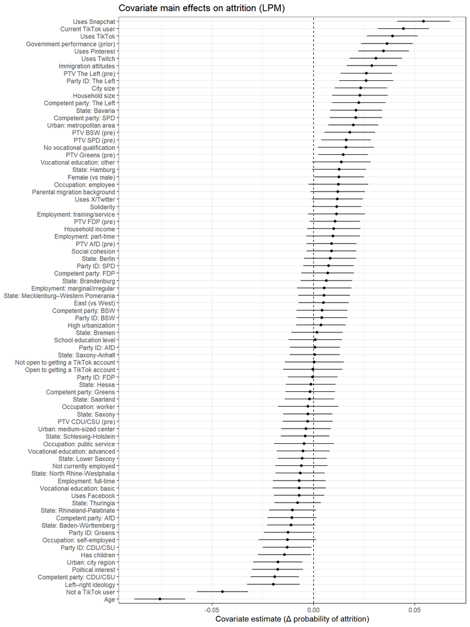

7 Fig. S6. Attrition (0/1) regressed on standardized pre-treatment covariates (main effects; linear probability models).

```r
fig_s6 <- results_main |>
  ggplot(aes(x = estimate, y = forcats::fct_reorder(label, estimate))) +
  geom_vline(xintercept = 0, linetype = "dashed") +
  geom_errorbar(aes(xmin = conf.low, xmax = conf.high), orientation = "y", width = 0) +
  geom_point() +
  labs(
    title = "Covariate main effects on attrition (LPM)",
    x = "Covariate estimate (Δ probability of attrition)",
    y = NULL
  ) +
  theme_bw()

write_fig(
  stem = "fig_s6_attrition_covariates",
  estimates = results_main,
  plot = fig_s6,
  width = 7,
  height = 12,
  dir = si_fig_dir
)
```

## 4.10 Table S9. Attrition by treatment condition

```r
attrit_counts <- df_w9_w10 |>
  mutate(arm = ifelse(workshop == 1, "Treatment", "Control")) |>
  count(arm, attrit) |>
  tidyr::complete(arm, attrit = c(0, 1), fill = list(n = 0))

attrit_summary <- attrit_counts |>
  group_by(arm) |>
  summarise(
    original_n = sum(n),
    retained = sum(n[attrit == 0]),
    attrited = sum(n[attrit == 1]),
    .groups = "drop"
  ) |>
  mutate(rate = 100 * attrited / original_n)

attrit_test <- df_w9_w10 |>
  mutate(treat = as.integer(workshop == 1)) |>
  lm_robust(attrit ~ treat, data = _)
attrit_test_td <- tidy(attrit_test, conf.int = TRUE) |> filter(term == "treat")
```

```r
overall <- attrit_summary |>
  summarise(
    arm = "Overall",
    original_n = sum(original_n),
    retained = sum(retained),
    attrited = sum(attrited)
  ) |>
  mutate(rate = 100 * attrited / original_n)

attrit_rows <- bind_rows(
  attrit_summary |> arrange(arm != "Control", arm),
  overall
)
d <- attrit_test_td$estimate
p_attrit <- attrit_test_td$p.value
ci <- c(attrit_test_td$conf.low, attrit_test_td$conf.high)

fmt_row <- function(r) {
  sprintf(
    "%s & %s & %s & %s & %.2f \\\\",
    r$arm, r$original_n, r$retained, r$attrited, r$rate
  )
}
tex <- c(
  "\\begin{table}",
  "\\caption{\\label{tab:attrition-summary}Attrition by treatment condition.}",
  "\\centering",
  "\\begin{threeparttable}",
  "\\begin{tabular}[t]{lrrrr}",
  "\\toprule",
  "Condition & Original $N$ & Retained & Attrited & Attrition rate (\\%)\\\\",
  "\\midrule",
  vapply(seq_len(nrow(attrit_rows)), function(i) fmt_row(attrit_rows[i, ]), character(1)),
  "\\bottomrule",
  "\\end{tabular}",
  "\\begin{tablenotes}",
  sprintf(
    "\\item Note: The treatment--control difference is %.2f percentage points (95\\%% CI: %.2f to %.2f; $p=%.3f$).",
    100 * d, 100 * ci[1], 100 * ci[2], p_attrit
  ),
  "\\end{tablenotes}",
  "\\end{threeparttable}",
  "\\end{table}"
)
writeLines(tex, file.path(tab_dir, "tab_s9_attrition.tex"))
knitr::kable(
  attrit_rows,
  digits = 2,
  caption = "Table S9. Attrition by treatment condition"
)
```

Table S9. Attrition by treatment condition

| arm | original_n | retained | attrited | rate |
| --- | --- | --- | --- | --- |
| Control | 2481 | 1824 | 657 | 26.48 |
| Treatment | 2464 | 1810 | 654 | 26.54 |
| Overall | 4945 | 3634 | 1311 | 26.51 |

## 4.11 Fig. S7. Attrition (0/1) regressed on the interaction between treatment and pre-treatment covariates

Stem: `fig_s7_attrition_interaction`.

```r
results_int <- lapply(covs, function(v) {
  as.formula(paste0("attrit ~ workshop * ", v)) |>
    lm_robust(data = df_w9_w10 |> mutate(across(all_of(v), scale))) |>
    tidy(conf.int = TRUE) |>
    filter(grepl(":", term))
}) |>
  bind_rows(.id = "label")
```

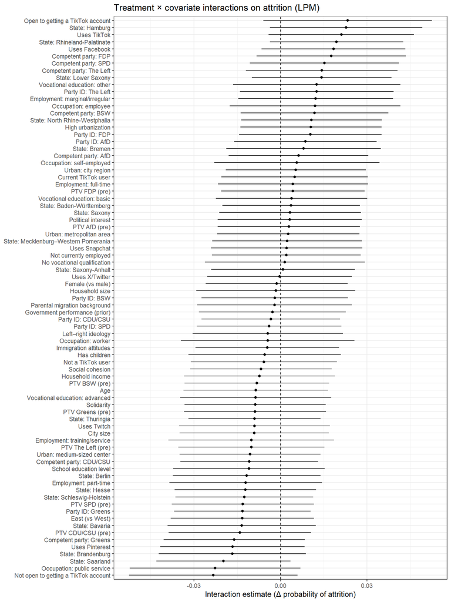

8 Fig. S7. Attrition (0/1) regressed on the interaction between treatment and pre-treatment covariates.

```r
fig_s7 <- results_int |>
  ggplot(aes(x = estimate, y = forcats::fct_reorder(label, estimate))) +
  geom_vline(xintercept = 0, linetype = "dashed") +
  geom_errorbar(aes(xmin = conf.low, xmax = conf.high), orientation = "y", width = 0) +
  geom_point() +
  labs(
    title = "Treatment × covariate interactions on attrition (LPM)",
    x = "Interaction estimate (Δ probability of attrition)",
    y = NULL
  ) +
  theme_bw()

write_fig(
  stem = "fig_s7_attrition_interaction",
  estimates = results_int,
  plot = fig_s7,
  width = 7,
  height = 12,
  dir = si_fig_dir
)
```

## 4.12 Fig. S8. Short-term pooled engagement effects among non-attriters

Stem: `fig_s8_fig1_nonattriters`. Figure 1 Wave 1 companion, restricted to respondents retained in Wave 2. Same six outcomes and Engagement / Attention super-headers as Figure 1.

```r
s8_outcomes <- c(l_outcomegroups$main, l_outcomegroups[["_other"]])
nonattrit_ids <- df_w9_w10 |>
  filter(attrit == 0) |>
  pull(id_w9) |>
  as.character()
df_w9_nonattrit <- datasets$wave_9 |>
  filter(as.character(ID) %in% nonattrit_ids)
estimates_s8 <- estimate_pooled_ates(df_w9_nonattrit, s8_outcomes) |>
  mutate(horizon = "Wave 1")
```

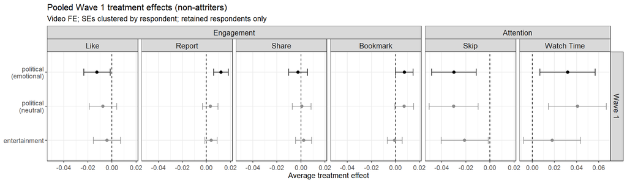

9 Fig. S8. Short-term pooled engagement effects (Like, Report, Share, Bookmark) by content strategy, restricted to non-attriters. Attrition-sensitivity check for manuscript Figure 1 showing results largely unchanged.

```r
fig_s8 <- estimates_s8 |>
  mutate(
    horizon = factor(horizon, levels = horizon_wave_levels),
    strategy = factor(as.character(strategy), levels = rev(strategy_order_article)),
    outcome = factor(outcome, levels = s8_outcomes),
    super = outcome_super(outcome),
    strat_color = as.character(strategy)
  ) |>
  ggplot(aes(x = estimate, y = strategy, color = strat_color)) +
  geom_vline(xintercept = 0, linetype = "dashed") +
  geom_errorbar(aes(xmin = conf.low, xmax = conf.high), width = 0.2) +
  geom_point(size = 1.8) +
  facet_nested(horizon ~ super + outcome, scales = "free_x") +
  facetted_pos_scales(x = shared_binary_x_scales(estimates_s8, s8_outcomes)) +
  scale_color_manual(values = strategy_color_values, guide = "none") +
  labs(
    x = "Average treatment effect",
    y = NULL,
    title = "Pooled Wave 1 treatment effects (non-attriters)",
    subtitle = "Video FE; SEs clustered by respondent; retained respondents only"
  ) +
  theme_bw(base_size = 10) +
  theme(
    axis.text.x = element_text(angle = 0, vjust = 0.5, hjust = 0.5, size = 9),
    axis.text.y = element_text(size = 9),
    strip.text = element_text(size = 10),
    panel.spacing.y = unit(6, "pt")
  )

write_fig(
  stem = "fig_s8_fig1_nonattriters",
  estimates = estimates_s8,
  plot = fig_s8,
  width = 12,
  height = 3.5,
  dir = si_fig_dir
)
```

## 4.13 Fig. S9. Long-term treatment effects excluding repeated video exposure

Stem: `fig_s9_longterm_no_repeat`. Wave 2 ATEs after dropping respondent–video pairs already shown in both waves (`shown_both_waves == 0`; flag merged in `1_data_prep.qmd`). Super-columns: Engagement (first four) and Attention (skip, watch time).

```r
df_w10_norepeat <- df_w10_no_repeated_videos
cat(
  "Wave 2 rows: ", nrow(datasets$wave_10),
  "; after dropping repeats (shown_both_waves == 0): ", nrow(df_w10_norepeat),
  "; dropped: ", nrow(datasets$wave_10) - nrow(df_w10_norepeat), "\n",
  sep = ""
)
```

```
Wave 2 rows: 121880; after dropping repeats (shown_both_waves == 0): 107250; dropped: 14630
```

```r
estimates_s9 <- bind_rows(
  estimate_pooled_ates(df_w10_norepeat, l_outcomegroups$main),
  estimate_pooled_ates(df_w10_norepeat, l_outcomegroups[["_other"]])
) |>
  mutate(horizon = "Wave 2")
```

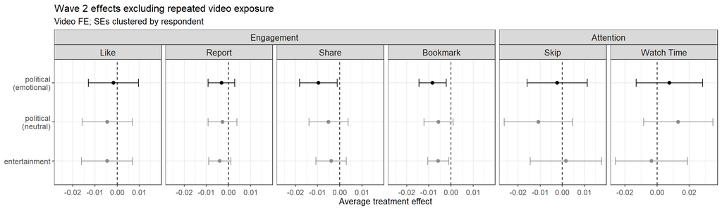

10 Fig. S9. Long-term treatment effects excluding repeated video exposure.

```r
fig_s9 <- estimates_s9 |>
  mutate(
    strategy = factor(as.character(strategy), levels = rev(strategy_order_article)),
    outcome = factor(
      outcome,
      levels = c(l_outcomegroups$main, l_outcomegroups[["_other"]])
    ),
    super = outcome_super(outcome),
    strat_color = as.character(strategy)
  ) |>
  ggplot(aes(x = estimate, y = strategy, color = strat_color)) +
  geom_vline(xintercept = 0, linetype = "dashed") +
  geom_errorbar(aes(xmin = conf.low, xmax = conf.high), width = 0.2) +
  geom_point(size = 1.8) +
  facet_nested(. ~ super + outcome, scales = "free_x") +
  facetted_pos_scales(
    x = shared_binary_x_scales(
      estimates_s9,
      c(l_outcomegroups$main, l_outcomegroups[["_other"]])
    )
  ) +
  scale_color_manual(values = strategy_color_values, guide = "none") +
  labs(
    x = "Average treatment effect",
    y = NULL,
    title = "Wave 2 effects excluding repeated video exposure",
    subtitle = "Video FE; SEs clustered by respondent"
  ) +
  theme_bw(base_size = 10) +
  theme(
    axis.text.x = element_text(angle = 0, vjust = 0.5, hjust = 0.5, size = 9),
    axis.text.y = element_text(size = 9),
    strip.text = element_text(size = 10)
  )

write_fig(
  stem = "fig_s9_longterm_no_repeat",
  estimates = estimates_s9,
  plot = fig_s9,
  width = 12,
  height = 3.5,
  dir = si_fig_dir
)
```

## 4.14 Tables S10–S11. AfD-specific triple interactions

```r
afd_3way_outcomes <- c("Like", "Share", "Bookmark", "Report")
afd_3way_coef_map <- list(
  "treatment_demeaned" = "Treatment (demeaned)",
  "AFD_supporter_demeaned" = "AfD supporter (demeaned)",
  "treatment_demeaned:AFD_supporter_demeaned" = "Treatment × AfD supporter (demeaned)",
  "treatment_demeaned:AFD_videos_demeaned" = "Treatment × AfD video (demeaned)",
  "AFD_supporter_demeaned:AFD_videos_demeaned" = "AfD supporter × AfD video (demeaned)",
  "treatment_demeaned:AFD_supporter_demeaned:AFD_videos_demeaned" =
    "Treatment × AfD supporter × AfD video (demeaned)"
)

prep_afd_3way <- function(df) {
  df |>
    filter(strategy_2 == strategies[1]) |>
    mutate(
      AFD_supporter = as.integer(party_preference_afd == 1),
      AFD_videos = as.integer(party == "AfD")
    ) |>
    mutate(
      treatment_demeaned = workshop_Treatment - mean(workshop_Treatment, na.rm = TRUE),
      AFD_supporter_demeaned = AFD_supporter - mean(AFD_supporter, na.rm = TRUE),
      AFD_videos_demeaned = AFD_videos - mean(AFD_videos, na.rm = TRUE)
    )
}

fit_afd_3way <- function(df, outcome_name) {
  feols(
    as.formula(paste0(
      v_outcomes[[outcome_name]],
      " ~ treatment_demeaned * AFD_supporter_demeaned * AFD_videos_demeaned | video"
    )),
    data = df,
    cluster = ~ID
  )
}

df_afd_3way <- prep_afd_3way(datasets$wave_9)
df_afd_3way_lt <- prep_afd_3way(datasets$wave_10)
models_afd_3way <- lapply(afd_3way_outcomes, function(Y) fit_afd_3way(df_afd_3way, Y)) |>
  setNames(afd_3way_outcomes)
models_afd_3way_lt <- lapply(afd_3way_outcomes, function(Y) fit_afd_3way(df_afd_3way_lt, Y)) |>
  setNames(afd_3way_outcomes)
```

💡 Liking in the demeaned triple interaction. The same formula is used for the other outcomes inside the helper.

```r
feols(
  videoLikep1r ~ treatment_demeaned * AFD_supporter_demeaned * AFD_videos_demeaned | video,
  cluster = ~ID
)
```

```r
# [!] Same specification as fit_afd_3way, written out for liking.
like_afd_hand <- feols(
  videoLikep1r ~ treatment_demeaned * AFD_supporter_demeaned * AFD_videos_demeaned | video,
  data = df_afd_3way,
  cluster = ~ID
)
stopifnot(all.equal(coef(like_afd_hand), coef(models_afd_3way$Like)))
coef(like_afd_hand)[c(
  "treatment_demeaned:AFD_videos_demeaned",
  "treatment_demeaned:AFD_supporter_demeaned",
  "treatment_demeaned:AFD_supporter_demeaned:AFD_videos_demeaned"
)]
```

```
                       treatment_demeaned:AFD_videos_demeaned
                                                  -0.01955443
                    treatment_demeaned:AFD_supporter_demeaned
                                                  -0.00713652
treatment_demeaned:AFD_supporter_demeaned:AFD_videos_demeaned
                                                  -0.04421226
```

```r
write_afd_3way <- function(models, dest_stem, caption, label, html_caption = caption) {
  write_tab_rds(models, dest_stem)
  texreg::texreg(
    models,
    file = file.path(tab_dir, paste0(dest_stem, ".tex")),
    digits = 3,
    include.ci = FALSE,
    custom.model.names = afd_3way_outcomes,
    custom.coef.map = afd_3way_coef_map,
    caption = caption,
    label = label,
    stars = texreg_stars
  )
  texreg::htmlreg(
    models,
    digits = 3,
    include.ci = FALSE,
    custom.model.names = afd_3way_outcomes,
    custom.coef.map = afd_3way_coef_map,
    caption = html_caption,
    stars = texreg_stars
  )
}

write_afd_3way(
  models_afd_3way,
  "tab_s10_afd_3way_short",
  "Treatment × AfD supporter × AfD video (all demeaned): Like/Share/Bookmark/Report (emotional political videos, Wave 1). Video FE; SEs clustered by respondent.",
  "tab:afd_video_3way_demeaned",
  "Table S10. Treatment × AfD supporter × AfD video (all demeaned): Like/Share/Bookmark/Report (emotional political videos, Wave 1). Video FE; SEs clustered by respondent."
)
```

```
The table was written to the file 'sn-tables/tab_s10_afd_3way_short.tex'.
```

Table S10. Treatment × AfD supporter × AfD video (all demeaned): Like/Share/Bookmark/Report (emotional political videos, Wave 1). Video FE; SEs clustered by respondent.

|  | Like | Share | Bookmark | Report |
| --- | --- | --- | --- | --- |
| Treatment (demeaned) | -0.012** | -0.003 | 0.007** | 0.013*** |
|  | (0.005) | (0.003) | (0.003) | (0.003) |
| AfD supporter (demeaned) | 0.005 | 0.008** | 0.003 | -0.003 |
|  | (0.006) | (0.004) | (0.003) | (0.003) |
| Treatment × AfD supporter (demeaned) | -0.007 | 0.000 | 0.001 | -0.015*** |
|  | (0.011) | (0.008) | (0.007) | (0.006) |
| Treatment × AfD video (demeaned) | -0.020** | -0.004 | 0.001 | 0.012** |
|  | (0.008) | (0.005) | (0.004) | (0.005) |
| AfD supporter × AfD video (demeaned) | 0.195*** | 0.044*** | 0.027*** | -0.044*** |
|  | (0.011) | (0.006) | (0.005) | (0.005) |
| Treatment × AfD supporter × AfD video (demeaned) | -0.044** | 0.014 | 0.002 | 0.000 |
|  | (0.022) | (0.013) | (0.011) | (0.009) |
| Num. obs. | 51990 | 51990 | 51990 | 51990 |
| Num. groups: video | 156 | 156 | 156 | 156 |
| R<sup>2</sup> (full model) | 0.034 | 0.007 | 0.005 | 0.014 |
| R<sup>2</sup> (proj model) | 0.014 | 0.002 | 0.001 | 0.005 |
| Adj. R<sup>2</sup> (full model) | 0.031 | 0.004 | 0.002 | 0.011 |
| Adj. R<sup>2</sup> (proj model) | 0.014 | 0.002 | 0.001 | 0.005 |

***p < 0.01; **p < 0.05; *p < 0.1

```r
write_afd_3way(
  models_afd_3way_lt,
  "tab_s11_afd_3way_long",
  "Treatment × AfD supporter × AfD video (all demeaned): Like/Share/Bookmark/Report (emotional political videos, Wave 2). Video FE; SEs clustered by respondent.",
  "tab:afd_video_3way_demeaned_longterm",
  "Table S11. Treatment × AfD supporter × AfD video (all demeaned): Like/Share/Bookmark/Report (emotional political videos, Wave 2). Video FE; SEs clustered by respondent."
)
```

```
The table was written to the file 'sn-tables/tab_s11_afd_3way_long.tex'.
```

Table S11. Treatment × AfD supporter × AfD video (all demeaned): Like/Share/Bookmark/Report (emotional political videos, Wave 2). Video FE; SEs clustered by respondent.

|  | Like | Share | Bookmark | Report |
| --- | --- | --- | --- | --- |
| Treatment (demeaned) | -0.001 | -0.009** | -0.009*** | -0.004 |
|  | (0.006) | (0.004) | (0.003) | (0.003) |
| AfD supporter (demeaned) | 0.005 | 0.017*** | 0.007* | 0.005 |
|  | (0.006) | (0.005) | (0.004) | (0.004) |
| Treatment × AfD supporter (demeaned) | -0.004 | -0.004 | -0.014* | -0.015* |
|  | (0.013) | (0.010) | (0.008) | (0.008) |
| Treatment × AfD video (demeaned) | -0.002 | -0.005 | -0.002 | 0.000 |
|  | (0.009) | (0.005) | (0.004) | (0.005) |
| AfD supporter × AfD video (demeaned) | 0.192*** | 0.046*** | 0.027*** | -0.036*** |
|  | (0.012) | (0.007) | (0.006) | (0.004) |
| Treatment × AfD supporter × AfD video (demeaned) | -0.001 | 0.001 | -0.006 | -0.003 |
|  | (0.024) | (0.014) | (0.011) | (0.009) |
| Num. obs. | 47728 | 47728 | 47728 | 47728 |
| Num. groups: video | 156 | 156 | 156 | 156 |
| R<sup>2</sup> (full model) | 0.032 | 0.008 | 0.007 | 0.009 |
| R<sup>2</sup> (proj model) | 0.013 | 0.004 | 0.003 | 0.003 |
| Adj. R<sup>2</sup> (full model) | 0.029 | 0.005 | 0.004 | 0.006 |
| Adj. R<sup>2</sup> (proj model) | 0.013 | 0.004 | 0.002 | 0.003 |

***p < 0.01; **p < 0.05; *p < 0.1

## 4.15 Table S12. Effect of digital literacy workshop on AfD identification

```r
df_w9_w10 <- df_w9_w10 |>
  mutate(
    party_id_w9_afd_demeaned = party_id_w9_afd - mean(party_id_w9_afd, na.rm = TRUE)
  )
models_s12 <- list(
  identification = lm_robust(
    party_id_w10_afd ~ workshop * party_id_w9_afd_demeaned,
    data = df_w9_w10
  ),
  conditional_afd = lm_robust(
    party_id_w10_afd ~ workshop,
    data = df_w9_w10 |> filter(party_id_w9_afd == 1)
  ),
  conditional_non_afd = lm_robust(
    party_id_w10_afd ~ workshop,
    data = df_w9_w10 |> filter(party_id_w9_afd == 0)
  )
)
```

💡 Continued AfD identification among baseline AfD identifiers.

```r
lm_robust(party_id_w10_afd ~ workshop, data = identifiers)
```

```r
# [!] Continued AfD identification among baseline AfD identifiers.
id_afd_hand <- lm_robust(
  party_id_w10_afd ~ workshop,
  data = df_w9_w10 |> filter(party_id_w9_afd == 1)
)
stopifnot(all.equal(
  coef(id_afd_hand)[["workshop"]],
  coef(models_s12$conditional_afd)[["workshop"]]
))
coef(summary(id_afd_hand))["workshop", c("Estimate", "Std. Error", "Pr(>|t|)")]
```

```
   Estimate  Std. Error    Pr(>|t|)
-0.05883522  0.02628356  0.02555573
```

```r
texreg::texreg(
  models_s12,
  file = file.path(tab_dir, "tab_s12_afd_identification.tex"),
  digits = 3,
  include.ci = FALSE,
  custom.model.names = c("All respondents", "AfD identifiers", "Non-AfD respondents"),
  custom.coef.map = list(
    "(Intercept)" = "Intercept",
    "workshop" = "Treatment (workshop)",
    "party_id_w9_afd_demeaned" = "AfD ID (Wave 1, demeaned)",
    "workshop:party_id_w9_afd_demeaned" = "Treatment × AfD ID (demeaned)"
  ),
  caption = "Effect of digital literacy workshop on AfD identification (Wave 2).",
  label = "tab:afd_maintained_support",
  stars = texreg_stars
)
```

```
The table was written to the file 'sn-tables/tab_s12_afd_identification.tex'.
```

```r
texreg::htmlreg(
  models_s12,
  digits = 3,
  include.ci = FALSE,
  custom.model.names = c("All respondents", "AfD identifiers", "Non-AfD respondents"),
  caption = "Table S12. Effect of digital literacy workshop on AfD identification (Wave 2).",
  stars = texreg_stars
)
```

Table S12. Effect of digital literacy workshop on AfD identification (Wave 2).

|  | All respondents | AfD identifiers | Non-AfD respondents |
| --- | --- | --- | --- |
| (Intercept) | 0.187*** | 0.911*** | 0.043*** |
|  | (0.005) | (0.016) | (0.005) |
| workshop | -0.018** | -0.059** | -0.010 |
|  | (0.007) | (0.026) | (0.007) |
| party_id_w9_afd_demeaned | 0.868*** |  |  |
|  | (0.017) |  |  |
| workshop:party_id_w9_afd_demeaned | -0.049* |  |  |
|  | (0.027) |  |  |
| R<sup>2</sup> | 0.672 | 0.008 | 0.001 |
| Adj. R<sup>2</sup> | 0.672 | 0.007 | 0.000 |
| Num. obs. | 3634 | 602 | 3032 |
| RMSE | 0.219 | 0.322 | 0.193 |

***p < 0.01; **p < 0.05; *p < 0.1

## 4.16 Fig. S10. Effect on party identification conditional on prior identification

Stem: `fig_s10_pid_by_prior`.

```r
maintained_results <- party_codes |>
  lapply(function(party) {
    w9 <- paste0("party_id_w9_", party)
    w10 <- paste0("party_id_w10_", party)
    df_tmp <- df_w9_w10 |>
      mutate(
        id_w9 = .data[[w9]],
        id_w9_demeaned = id_w9 - mean(id_w9, na.rm = TRUE),
        id_w10 = .data[[w10]]
      )
    m_all <- lm_robust(id_w10 ~ workshop * id_w9_demeaned, data = df_tmp)
    m_id <- lm_robust(id_w10 ~ workshop, data = df_tmp |> filter(id_w9 == 1))
    m_non <- lm_robust(id_w10 ~ workshop, data = df_tmp |> filter(id_w9 == 0))
    bind_rows(
      tidy(m_all) |> filter(term == "workshop") |> mutate(group = "All respondents"),
      tidy(m_id) |> filter(term == "workshop") |> mutate(group = "Identifiers"),
      tidy(m_non) |> filter(term == "workshop") |> mutate(group = "Non-identifiers")
    ) |>
      mutate(party = party_names[[party]])
  }) |>
  bind_rows()

party_order_maintained <- maintained_results |>
  filter(group == "All respondents") |>
  arrange(estimate) |>
  pull(party)
maintained_results <- maintained_results |>
  mutate(
    party = factor(party, levels = party_order_maintained),
    group = factor(group, levels = c("All respondents", "Identifiers", "Non-identifiers"))
  )
```

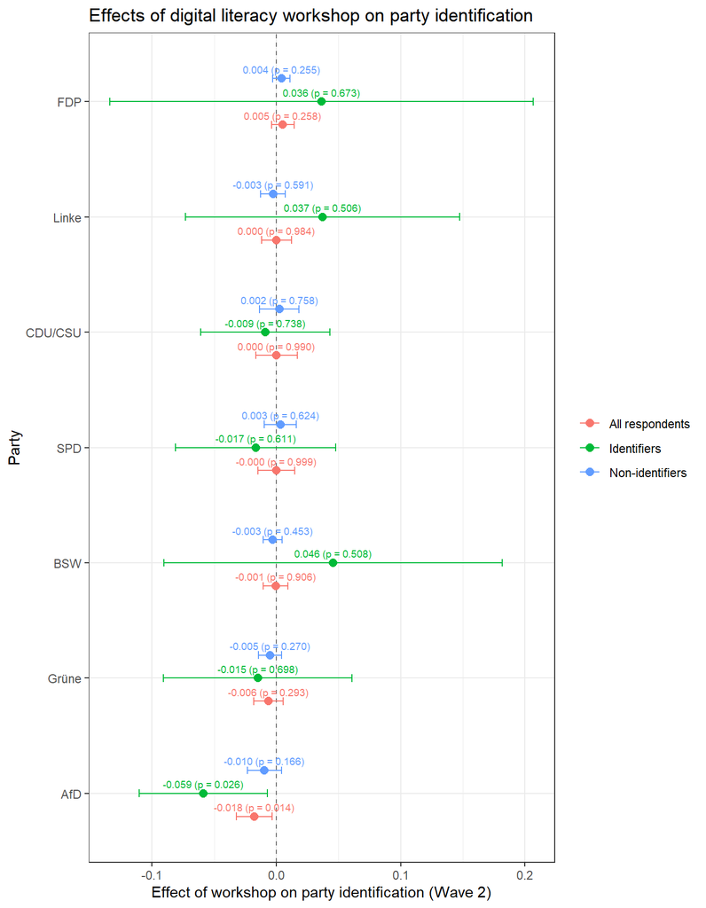

11 Fig. S10. Effect on party identification conditional on prior identification.

```r
fig_s10 <- maintained_results |>
  ggplot(aes(x = estimate, y = party, color = group)) +
  geom_vline(xintercept = 0, linetype = "dashed", alpha = 0.5) +
  geom_point(position = position_dodge(width = 0.6), size = 2.5) +
  geom_errorbar(
    aes(xmin = conf.low, xmax = conf.high),
    orientation = "y",
    position = position_dodge(width = 0.6),
    width = 0.2
  ) +
  geom_text(
    aes(label = sprintf("%.3f (p = %.3f)", estimate, p.value), group = group),
    position = position_dodge(width = 0.6),
    hjust = 0.5, vjust = -0.7, size = 2.5, show.legend = FALSE
  ) +
  labs(
    x = "Effect of workshop on party identification (Wave 2)",
    y = "Party",
    color = NULL,
    title = "Effects of digital literacy workshop on party identification"
  ) +
  theme_bw()

write_fig(
  stem = "fig_s10_pid_by_prior",
  estimates = maintained_results,
  plot = fig_s10,
  width = 7,
  height = 9,
  dir = si_fig_dir
)
```

## 4.17 Fig. S11. Change in party identification, Wave 1 to Wave 2, full sample

Stem: `fig_s11_pid_transitions`. Figs. S12–S13 use the same transition construction for treatment and control.

```r
build_pid_lodes <- function(df_input) {
  labs <- party_names
  from <- df_input |>
    select(id_w9, starts_with("party_id_w9")) |>
    pivot_longer(-id_w9, names_to = "var", values_to = "val") |>
    filter(val == 1) |>
    transmute(
      id_w9,
      from_party = recode(sub("^party_id_w9_(.*)$", "\\1", var), !!!labs)
    )
  to <- df_input |>
    select(id_w9, starts_with("party_id_w10")) |>
    pivot_longer(-id_w9, names_to = "var", values_to = "val") |>
    filter(val == 1) |>
    transmute(
      id_w9,
      to_party = recode(sub("^party_id_w10_(.*)$", "\\1", var), !!!labs)
    )
  transitions <- inner_join(from, to, by = "id_w9") |>
    count(`Wave 1` = from_party, `Wave 2` = to_party, name = "Freq")
  totN <- sum(transitions$Freq)
  share_w9 <- transitions |>
    group_by(`Wave 1`) |>
    summarise(s9 = sum(Freq) / totN, .groups = "drop")
  share_w10 <- transitions |>
    group_by(`Wave 2`) |>
    summarise(s10 = sum(Freq) / totN, .groups = "drop")
  net_pp <- share_w10 |>
    left_join(share_w9, by = c("Wave 2" = "Wave 1")) |>
    mutate(
      delta_pp = (s10 - s9) * 100,
      label_right = sprintf("%s (%+.1f pp)", `Wave 2`, delta_pp)
    ) |>
    select(`Wave 2`, label_right)
  lodes <- transitions |>
    mutate(Share = Freq / totN) |>
    to_lodes_form(axes = 1:2, id = "alluvium") |>
    mutate(
      x = factor(x, levels = c("Wave 1", "Wave 2")),
      stratum_lab = ifelse(
        x == "Wave 2",
        net_pp$label_right[match(stratum, net_pp$`Wave 2`)],
        as.character(stratum)
      )
    )
  party_cols <- c(
    "CDU/CSU" = "#000000",
    "SPD" = "#E3000F",
    "Grüne" = "#0DB02B",
    "FDP" = "#FFED00",
    "Linke" = "#E2382A",
    "AfD" = "#009EE0",
    "BSW" = "#18A19A"
  )
  list(lodes = lodes, party_cols = party_cols)
}

plot_pid_alluvial <- function(lodes, party_cols, title_text) {
  # Labels sit outside the columns. Repulsion keeps small parties legible.
  label_layer <- function(side, nudge, hjust) {
    ggrepel::geom_text_repel(
      data = lodes |> filter(x == side),
      stat = "stratum",
      aes(label = stratum_lab),
      size = 3,
      lineheight = 0.9,
      direction = "y",
      nudge_x = nudge,
      hjust = hjust,
      segment.size = 0.25,
      segment.color = "grey40",
      box.padding = 0.2,
      point.padding = 0.05,
      min.segment.length = 0,
      max.overlaps = Inf,
      seed = 1,
      show.legend = FALSE
    )
  }
  ggplot(
    lodes,
    aes(x = x, stratum = stratum, alluvium = alluvium, y = Share, fill = stratum)
  ) +
    geom_alluvium(alpha = 0.65, color = NA, knot.pos = 0.35, width = 0.22) +
    geom_stratum(width = 0.22, fill = "white", color = "black", linewidth = 0.3) +
    label_layer("Wave 1", nudge = -0.42, hjust = 1) +
    label_layer("Wave 2", nudge = 0.42, hjust = 0) +
    scale_fill_manual(values = party_cols, guide = "none") +
    scale_x_discrete(labels = c("Wave 1", "Wave 2"), expand = expansion(add = c(0.85, 1.05))) +
    labs(x = NULL, y = NULL, title = title_text) +
    coord_cartesian(clip = "off") +
    theme_minimal(base_size = 12) +
    theme(
      plot.title = element_text(hjust = 0.5, face = "bold"),
      plot.margin = margin(10, 36, 10, 28),
      panel.grid = element_blank(),
      axis.text.y = element_blank()
    )
}

pid_overall <- build_pid_lodes(df_w9_w10)
```

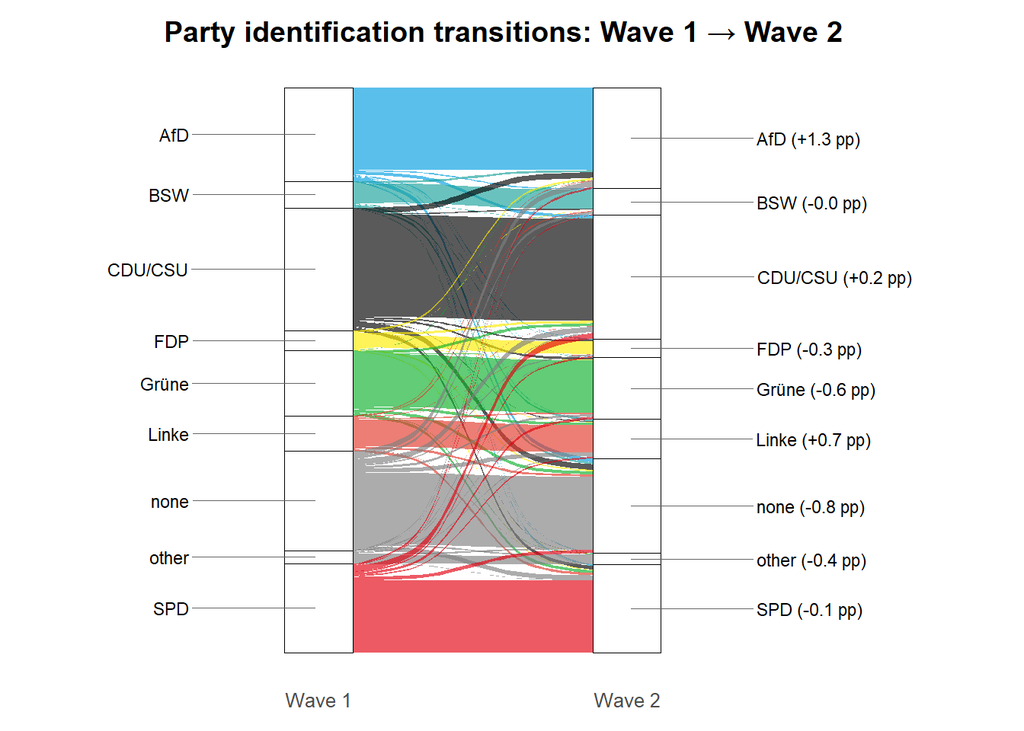

12 Fig. S11. Change in party identification, Wave 1 to Wave 2, full sample.

```r
fig_s11 <- plot_pid_alluvial(
  pid_overall$lodes, pid_overall$party_cols,
  "Party identification transitions: Wave 1 \u2192 Wave 2"
)
write_fig(
  stem = "fig_s11_pid_transitions",
  estimates = pid_overall,
  plot = fig_s11,
  width = 9,
  height = 7,
  dir = si_fig_dir
)
```

```r
pid_treat <- build_pid_lodes(df_w9_w10 |> filter(workshop == 1))
```

## 4.18 Fig. S12. Change in party identification, Wave 1 to Wave 2, treatment group

Stem: `fig_s12_pid_transitions_treat`.

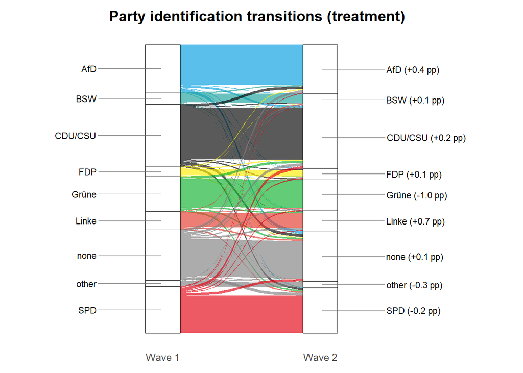

13 Fig. S12. Change in party identification, Wave 1 to Wave 2, treatment group.

```r
fig_s12 <- plot_pid_alluvial(
  pid_treat$lodes, pid_treat$party_cols,
  "Party identification transitions (treatment)"
)
write_fig(
  stem = "fig_s12_pid_transitions_treat",
  estimates = pid_treat,
  plot = fig_s12,
  width = 9,
  height = 7,
  dir = si_fig_dir
)
```

```r
pid_control <- build_pid_lodes(df_w9_w10 |> filter(workshop == 0))
```

## 4.19 Fig. S13. Change in party identification, Wave 1 to Wave 2, control group

Stem: `fig_s13_pid_transitions_control`.

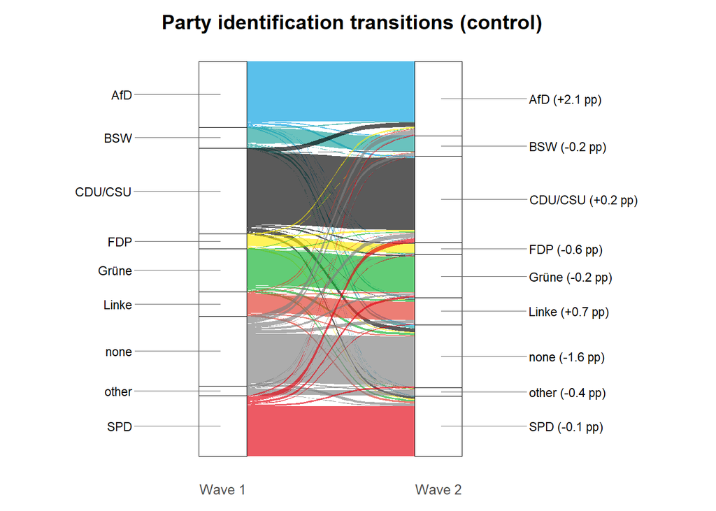

14 Fig. S13. Change in party identification, Wave 1 to Wave 2, control group.

```r
fig_s13 <- plot_pid_alluvial(
  pid_control$lodes, pid_control$party_cols,
  "Party identification transitions (control)"
)
write_fig(
  stem = "fig_s13_pid_transitions_control",
  estimates = pid_control,
  plot = fig_s13,
  width = 9,
  height = 7,
  dir = si_fig_dir
)
```

## 4.20 Fig. S14. Effects of the digital literacy workshop on propensity to vote (PTV)

Stem: `fig_s14_ptv`. By party and prior identification.

```r
# Outcome is the post-treatment level. Pre-treatment PTV is demeaned inside
# the estimation sample, so the workshop coefficient is the effect at that
# sample's mean pre-treatment PTV.
fit_ptv_group <- function(data, post_var, pre_var) {
  d <- data |>
    filter(is.finite(.data[[post_var]]), is.finite(.data[[pre_var]]), !is.na(workshop)) |>
    mutate(pre_within = .data[[pre_var]] - mean(.data[[pre_var]]))
  lm_robust(
    stats::reformulate("workshop * pre_within", response = post_var),
    data = d
  )
}

estimate_ptv_by_id <- function(post_prefix) {
  party_codes |>
    lapply(function(party) {
      pre_var <- paste0("ptv_w9_pre_", party)
      post_var <- paste0(post_prefix, party)
      id_var <- paste0("party_id_w9_", party)
      m_all <- fit_ptv_group(df_w9_w10, post_var, pre_var)
      m_id <- fit_ptv_group(df_w9_w10 |> filter(.data[[id_var]] == 1), post_var, pre_var)
      m_non <- fit_ptv_group(df_w9_w10 |> filter(.data[[id_var]] == 0), post_var, pre_var)
      bind_rows(
        tidy(m_all) |> filter(term == "workshop") |> mutate(group = "All respondents"),
        tidy(m_id) |> filter(term == "workshop") |> mutate(group = "Identifiers"),
        tidy(m_non) |> filter(term == "workshop") |> mutate(group = "Non-identifiers")
      ) |>
        mutate(party = party_names[[party]])
    }) |>
    bind_rows()
}

ptv_short <- estimate_ptv_by_id("ptv_w9_post_")
ptv_long <- estimate_ptv_by_id("ptv_w10_")
group_levels <- c("All respondents", "Identifiers", "Non-identifiers")
party_order_ptv <- ptv_short |>
  filter(group == "All respondents") |>
  arrange(estimate) |>
  pull(party) |>
  as.character()
estimates_ptv <- bind_rows(
  ptv_short |> mutate(horizon = "Wave 1"),
  ptv_long |> mutate(horizon = "Wave 2")
) |>
  mutate(
    horizon = factor(horizon, levels = horizon_wave_levels),
    party = factor(as.character(party), levels = party_order_ptv),
    group = factor(as.character(group), levels = group_levels)
  )
```

💡 AfD identifiers. The outcome is post-treatment PTV. Pre-treatment PTV is demeaned inside this subset, so the workshop coefficient is the effect at the identifiers’ mean.

```r
lm_robust(ptv_post_afd ~ workshop * pre_within, data = identifiers)
```

```r
# [!] AfD identifiers. Post-treatment PTV; pre-treatment PTV demeaned in this subset.
fit_afd_id_ptv <- function(post_var) {
  d <- df_w9_w10 |>
    filter(party_id_w9_afd == 1, is.finite(.data[[post_var]]), is.finite(ptv_w9_pre_afd)) |>
    mutate(pre_within = ptv_w9_pre_afd - mean(ptv_w9_pre_afd))
  lm_robust(stats::reformulate("workshop * pre_within", response = post_var), data = d)
}
ptv_afd_w1_hand <- fit_afd_id_ptv("ptv_w9_post_afd")
ptv_afd_w2_hand <- fit_afd_id_ptv("ptv_w10_afd")
hand_ptv <- tibble(
  horizon = c("Wave 1", "Wave 2"),
  estimate = c(
    coef(ptv_afd_w1_hand)[["workshop"]],
    coef(ptv_afd_w2_hand)[["workshop"]]
  )
)
helper_ptv <- estimates_ptv |>
  filter(party == "AfD", group == "Identifiers") |>
  arrange(horizon) |>
  select(horizon, estimate)
stopifnot(all.equal(hand_ptv$estimate, helper_ptv$estimate))
hand_ptv
```

```
# A tibble: 2 × 2
  horizon estimate
  <chr>      <dbl>
1 Wave 1   -0.0197
2 Wave 2   -0.0329
```

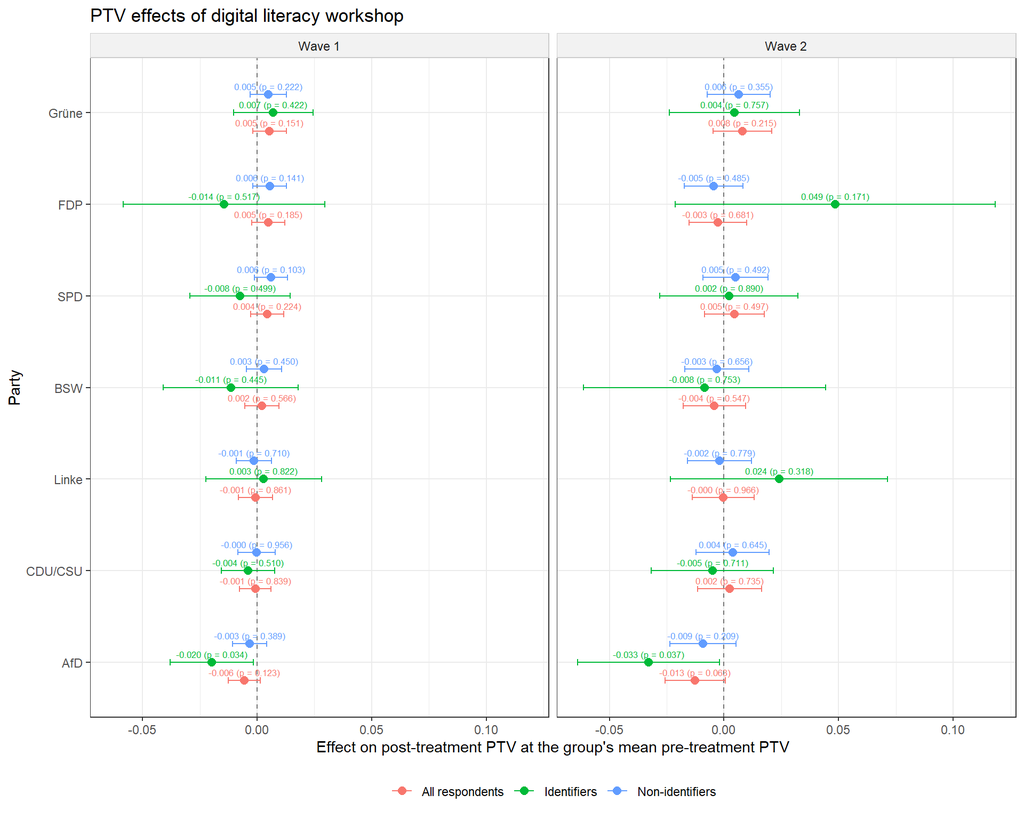

15 Fig. S14. Effects of the digital literacy workshop on propensity to vote (PTV), by party and prior identification.

```r
dodge_ptv <- position_dodge(width = 0.6)
fig_s14 <- estimates_ptv |>
  ggplot(aes(x = estimate, y = party, color = group)) +
  geom_vline(xintercept = 0, linetype = "dashed", alpha = 0.5) +
  geom_point(position = dodge_ptv, size = 2.5) +
  geom_errorbar(
    aes(xmin = conf.low, xmax = conf.high),
    orientation = "y",
    position = dodge_ptv,
    width = 0.2
  ) +
  geom_text(
    aes(label = sprintf("%.3f (p = %.3f)", estimate, p.value), group = group),
    position = dodge_ptv, hjust = 0.5, vjust = -0.7, size = 2.2, show.legend = FALSE
  ) +
  facet_grid(cols = vars(horizon)) +
  labs(
    x = "Effect on post-treatment PTV at the group's mean pre-treatment PTV",
    y = "Party",
    color = NULL,
    title = "PTV effects of digital literacy workshop"
  ) +
  theme_bw(base_size = 11) +
  theme(
    legend.position = "bottom",
    strip.background = element_rect(fill = "grey95", color = "grey80")
  )

write_fig(
  stem = "fig_s14_ptv",
  estimates = estimates_ptv,
  plot = fig_s14,
  width = 10,
  height = 8,
  dir = si_fig_dir
)
```

## 4.21 Table S13. PAP H1a reconciliation

```r
df_h1_emo <- datasets$wave_9 |>
  filter(strategy_2 == strategies[1]) |>
  mutate(
    engage = rowMeans(cbind(videoSharep1r, videoLikep1r, videoBookmarkp1r), na.rm = FALSE)
  )
h1_outcomes <- c(
  Like = v_outcomes[["Like"]],
  Share = v_outcomes[["Share"]],
  Bookmark = v_outcomes[["Bookmark"]],
  Engage = "engage"
)
models_h1 <- lapply(h1_outcomes, function(y) {
  feols(as.formula(paste0(y, " ~ workshop_Treatment | video")), data = df_h1_emo, cluster = ~ID)
})
h1_comp <- c("Like", "Share", "Bookmark")
p_h1_raw <- sapply(models_h1[h1_comp], \(m) coeftable(m)["workshop_Treatment", "Pr(>|t|)"])
p_h1_bh <- p.adjust(p_h1_raw, method = "BH")
h1_bh_row <- c(sprintf("%.3f", p_h1_bh[h1_comp]), "---")
names(h1_bh_row) <- names(models_h1)
```

```r
h1_caption <- paste(
  "PAP H1a reconciliation: Like, Share, Bookmark, and engage = mean(share, like, bookmark)",
  "on emotional political videos (Wave 1). Video FE; SEs clustered by respondent.",
  "Row p (BH FDR): Benjamini--Hochberg FDR correction across the three component tests",
  "(Like, Share, Bookmark); Engage is not in that family."
)
texreg::texreg(
  models_h1,
  file = file.path(tab_dir, "tab_s13_pap_h1a.tex"),
  digits = 3,
  include.ci = FALSE,
  custom.model.names = names(models_h1),
  custom.coef.map = list("workshop_Treatment" = "Treatment"),
  custom.gof.rows = list("p (BH FDR)" = unname(h1_bh_row)),
  caption = h1_caption,
  label = "tab:pap_h1a_engage_emotional",
  stars = texreg_stars
)
```

```
The table was written to the file 'sn-tables/tab_s13_pap_h1a.tex'.
```

```r
texreg::htmlreg(
  models_h1,
  digits = 3,
  include.ci = FALSE,
  custom.model.names = names(models_h1),
  custom.coef.map = list("workshop_Treatment" = "Treatment"),
  custom.gof.rows = list("p (BH FDR)" = unname(h1_bh_row)),
  caption = paste("Table S13.", h1_caption),
  stars = texreg_stars
)
```

Table S13. PAP H1a reconciliation: Like, Share, Bookmark, and engage = mean(share, like, bookmark) on emotional political videos (Wave 1). Video FE; SEs clustered by respondent. Row p (BH FDR): Benjamini–Hochberg FDR correction across the three component tests (Like, Share, Bookmark); Engage is not in that family.

|  | Like | Share | Bookmark | Engage |
| --- | --- | --- | --- | --- |
| Treatment | -0.012** | -0.003 | 0.007** | -0.002 |
|  | (0.005) | (0.003) | (0.003) | (0.003) |
| p (BH FDR) | 0.040 | 0.411 | 0.040 | — |
| Num. obs. | 51990 | 51990 | 51990 | 51990 |
| Num. groups: video | 156 | 156 | 156 | 156 |
| R<sup>2</sup> (full model) | 0.021 | 0.005 | 0.004 | 0.017 |
| R<sup>2</sup> (proj model) | 0.000 | 0.000 | 0.000 | 0.000 |
| Adj. R<sup>2</sup> (full model) | 0.018 | 0.002 | 0.001 | 0.014 |
| Adj. R<sup>2</sup> (proj model) | 0.000 | 0.000 | 0.000 | 0.000 |

***p < 0.01; **p < 0.05; *p < 0.1

## 4.22 Table S14. Pairwise outcome correlations

Pairwise outcome correlations on emotionally manipulative political videos, Wave 1. Cells expanded to three rows ($r_T$, $r_C$, $\Delta$) with a rule after each outcome group. Compiled SI Table S15 (PAP reconciliation) is written in the SI `.tex`.

```r
oc_labs <- c("Like", "Share", "Bookmark", "Report", "Watch time", "Skip")
oc_vars <- c(
  Like = "videoLikep1r",
  Share = "videoSharep1r",
  Bookmark = "videoBookmarkp1r",
  Report = "videoCommentTickedp1r",
  `Watch time` = "watch_percentage_",
  Skip = "skipped_video_"
)
star_p <- function(p) {
  if (!is.finite(p)) return("")
  if (p < 0.01) return("***")
  if (p < 0.05) return("**")
  if (p < 0.10) return("*")
  ""
}
fmt_r <- function(x) {
  if (!is.finite(x)) return("")
  sprintf("%0.2f", x)
}
pair_cor <- function(x, y) {
  ok <- is.finite(x) & is.finite(y)
  n <- sum(ok)
  if (n < 3) return(list(r = NA_real_, n = n))
  list(r = suppressWarnings(cor(x[ok], y[ok])), n = n)
}
cluster_cor_diff_p <- function(yi, yj, mod, id) {
  ok <- is.finite(yi) & is.finite(yj) & is.finite(mod) & !is.na(id)
  if (sum(ok) < 8L) return(NA_real_)
  mod_ok <- as.numeric(mod[ok])
  if (length(unique(mod_ok)) < 2L) return(NA_real_)
  yi_ok <- as.numeric(yi[ok])
  yj_ok <- as.numeric(yj[ok])
  s_i <- stats::sd(yi_ok)
  s_j <- stats::sd(yj_ok)
  if (!is.finite(s_i) || !is.finite(s_j) || s_i <= 0 || s_j <= 0) return(NA_real_)
  d <- data.frame(
    yi_z = as.numeric(scale(yi_ok)),
    yj_z = as.numeric(scale(yj_ok)),
    mod = mod_ok,
    ID = as.character(id[ok]),
    stringsAsFactors = FALSE
  )
  fit <- tryCatch(feols(yi_z ~ yj_z * mod, data = d, cluster = ~ID), error = function(e) NULL)
  if (is.null(fit)) return(NA_real_)
  td <- broom::tidy(fit)
  hit <- td$term[grepl(":", td$term, fixed = TRUE)]
  if (length(hit) != 1L) return(NA_real_)
  as.numeric(td$p.value[td$term == hit])
}
oc_num <- function(x) {
  if (inherits(x, "haven_labelled")) x <- haven::zap_labels(x)
  as.numeric(x)
}
df_oc_tc <- datasets$wave_9 |>
  filter(strategy_2 == strategies[1]) |>
  transmute(
    ID = as.character(ID),
    mod_treat = as.integer(workshop_Treatment),
    across(all_of(unname(oc_vars)), oc_num)
  ) |>
  rename(!!!setNames(unname(oc_vars), oc_labs))

cells_tc <- {
  dat_a <- df_oc_tc[df_oc_tc$mod_treat == 1, , drop = FALSE]
  dat_b <- df_oc_tc[df_oc_tc$mod_treat == 0, , drop = FALSE]
  out <- vector("list", length(oc_labs) * length(oc_labs))
  k <- 0L
  for (i in seq_along(oc_labs)) {
    for (j in seq_along(oc_labs)) {
      k <- k + 1L
      rn <- oc_labs[i]
      cn <- oc_labs[j]
      if (identical(rn, cn)) {
        out[[k]] <- tibble(row = rn, col = cn, r_a = NA_real_, r_b = NA_real_,
                           delta = NA_real_, p = NA_real_, blank = TRUE)
        next
      }
      pa <- pair_cor(dat_a[[rn]], dat_a[[cn]])
      pb <- pair_cor(dat_b[[rn]], dat_b[[cn]])
      p <- cluster_cor_diff_p(df_oc_tc[[rn]], df_oc_tc[[cn]], df_oc_tc$mod_treat, df_oc_tc$ID)
      out[[k]] <- tibble(
        row = rn, col = cn, r_a = pa$r, r_b = pb$r, delta = pa$r - pb$r, p = p, blank = FALSE
      )
    }
  }
  bind_rows(out)
}
```

```r
star_tex <- function(p) {
  s <- star_p(p)
  if (!nzchar(s)) return("")
  paste0("^{", s, "}")
}
val_tex <- function(x, p = NA, blank = FALSE) {
  if (isTRUE(blank) || !is.finite(x)) return("")
  paste0(fmt_r(x), star_tex(p))
}
align <- paste0("ll", paste(rep("c", length(oc_labs)), collapse = ""))
header <- paste(c("Outcome", "", oc_labs), collapse = " & ")
body <- character(0)
html_mat <- matrix("", nrow = 3 * length(oc_labs), ncol = 2 + length(oc_labs))
colnames(html_mat) <- c("Outcome", "Stat", oc_labs)
html_i <- 0L
for (i in seq_along(oc_labs)) {
  rn <- oc_labs[i]
  row_t <- row_c <- row_d <- character(length(oc_labs))
  for (j in seq_along(oc_labs)) {
    cell <- cells_tc |> filter(row == rn, col == oc_labs[j])
    row_t[j] <- val_tex(cell$r_a, blank = cell$blank)
    row_c[j] <- val_tex(cell$r_b, blank = cell$blank)
    row_d[j] <- val_tex(cell$delta, cell$p, blank = cell$blank)
  }
  body <- c(
    body,
    paste(c(rn, "$r_{T}$", row_t), collapse = " & "),
    paste(c("", "$r_{C}$", row_c), collapse = " & "),
    paste0("\\rowcolor{ocrow} ", paste(c("", "$\\Delta$", row_d), collapse = " & "))
  )
  html_mat[html_i <- html_i + 1L, ] <- c(rn, "r_T", row_t)
  html_mat[html_i <- html_i + 1L, ] <- c("", "r_C", row_c)
  html_mat[html_i <- html_i + 1L, ] <- c("", "Delta", gsub("\\^\\{([^}]+)\\}", "*\\1", row_d, perl = TRUE))
}
note <- paste0(
  "\\multicolumn{", 2 + length(oc_labs), "}{l}{\\scriptsize{",
  "$^{***}p<0.01$; $^{**}p<0.05$; $^{*}p<0.10$ (clustered interaction: standardized $Y_i \\sim Y_j \\times$ group, cluster ID). Pairwise-complete $n$.",
  "}}"
)
body_grouped <- character(0)
for (g in seq_along(oc_labs)) {
  i0 <- (g - 1L) * 3L
  body_grouped <- c(
    body_grouped,
    paste0(body[i0 + 1L], " \\\\"),
    paste0(body[i0 + 2L], " \\\\"),
    paste0(body[i0 + 3L], " \\\\"),
    if (g < length(oc_labs)) "\\hline" else NULL
  )
}
tex <- c(
  "\\begin{table}",
  "\\begin{center}",
  "\\setlength{\\tabcolsep}{4pt}",
  paste0("\\begin{tabular}{", align, "}"),
  "\\hline",
  paste0(header, " \\\\"),
  "\\hline",
  body_grouped,
  "\\hline",
  paste0(note, " \\\\"),
  "\\end{tabular}",
  paste0(
    "\\caption{Pairwise outcome correlations (emotionally manipulative political videos; ",
    "video--respondent rows, Wave 1 only). ",
    "Within each outcome, three rows report $r_{T}$, $r_{C}$, and $\\Delta=r_{T}-r_{C}$ ",
    "with clustered-interaction stars ($*/**/***$) on $\\Delta$. Diagonal blank. ",
    "The correlations are symmetric, and both triangles are shown. ",
    "Stars on $\\Delta$ are not symmetric: each star is a clustered regression of one ",
    "standardized outcome on the other interacted with treatment.}"
  ),
  "\\label{tab:outcome_cors_treat_ctrl}",
  "\\end{center}",
  "\\end{table}"
)
writeLines(tex, file.path(tab_dir, "tab_s14_outcome_cors.tex"))
knitr::kable(
  html_mat,
  caption = "Table S14. Pairwise outcome correlations (emotionally manipulative political videos; video-respondent rows, Wave 1). Groups of three rows: r_T, r_C, Delta. Correlations are symmetric and both triangles are shown. Stars on Delta are not: each star is a clustered regression of one standardized outcome on the other interacted with treatment.",
  align = c("l", "l", rep("c", length(oc_labs))),
  escape = FALSE,
  row.names = FALSE
)
```

Table S14. Pairwise outcome correlations (emotionally manipulative political videos; video-respondent rows, Wave 1). Groups of three rows: r_T, r_C, Delta. Correlations are symmetric and both triangles are shown. Stars on Delta are not: each star is a clustered regression of one standardized outcome on the other interacted with treatment.

| Outcome | Stat | Like | Share | Bookmark | Report | Watch time | Skip |
| --- | --- | --- | --- | --- | --- | --- | --- |
| Like | r_T |  | 0.18 | 0.07 | -0.01 | 0.26 | -0.21 |
|  | r_C |  | 0.20 | 0.13 | 0.01 | 0.30 | -0.24 |
|  | Delta |  | -0.01 | -0.06**** | -0.02 | -0.04**** | 0.03**** |
| Share | r_T | 0.18 |  | 0.13 | 0.04 | 0.13 | -0.10 |
|  | r_C | 0.20 |  | 0.19 | 0.06 | 0.15 | -0.12 |
|  | Delta | -0.01 |  | -0.06*** | -0.02 | -0.02*** | 0.02** |
| Bookmark | r_T | 0.07 | 0.13 |  | 0.08 | 0.11 | -0.09 |
|  | r_C | 0.13 | 0.19 |  | 0.13 | 0.11 | -0.10 |
|  | Delta | -0.06** | -0.06 |  | -0.05 | -0.01 | 0.00 |
| Report | r_T | -0.01 | 0.04 | 0.08 |  | 0.12 | -0.11 |
|  | r_C | 0.01 | 0.06 | 0.13 |  | 0.09 | -0.07 |
|  | Delta | -0.02 | -0.02 | -0.05 |  | 0.03**** | -0.04**** |
| Watch time | r_T | 0.26 | 0.13 | 0.11 | 0.12 |  | -0.84 |
|  | r_C | 0.30 | 0.15 | 0.11 | 0.09 |  | -0.83 |
|  | Delta | -0.04 | -0.02 | -0.01 | 0.03 |  | -0.01 |
| Skip | r_T | -0.21 | -0.10 | -0.09 | -0.11 | -0.84 |  |
|  | r_C | -0.24 | -0.12 | -0.10 | -0.07 | -0.83 |  |
|  | Delta | 0.03 | 0.02 | 0.00 | -0.04 | -0.01*** |  |

## 4.23 Fig. S15. Main engagement patterns without video fixed effects

Stem: `fig_s15_fig1_nofe`. Figure 1 companion without video fixed effects (cluster ID retained). The former ellipses figure is commented out of the SI, so this is Figure S15. Six outcomes with Engagement | Attention super-headers, as in Figure 1.

```r
s15_outcomes <- c(l_outcomegroups$main, l_outcomegroups[["_other"]])

estimates_s15 <- lapply(c("wave_9", "wave_10"), function(D) {
  df <- datasets[[D]]
  lapply(s15_outcomes, function(Y) {
    lapply(unique(as.character(df$strategy_2)), function(S) {
      feols(
        as.formula(paste(v_outcomes[[Y]], "~ workshop_Treatment")),
        data = df |> filter(strategy_2 == S),
        cluster = ~ID
      ) |>
        tidy(conf.int = TRUE) |>
        filter(term == "workshop_Treatment") |>
        mutate(
          outcome = Y,
          strategy = S,
          horizon = if (D == "wave_9") "Wave 1" else "Wave 2"
        )
    }) |> bind_rows()
  }) |> bind_rows()
}) |>
  bind_rows()
```

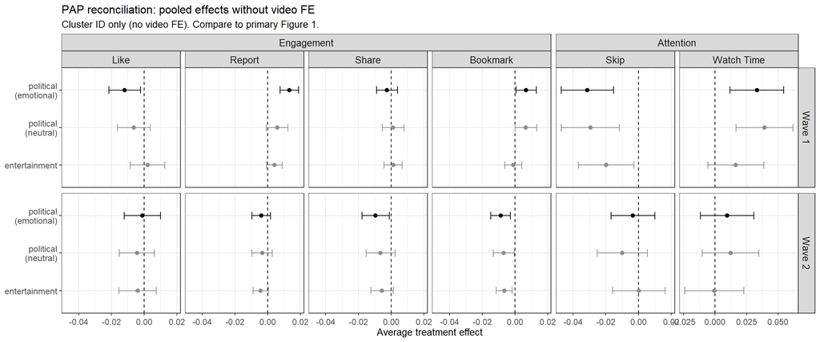

16 Fig. S15. Main engagement patterns without video fixed effects (respondent-clustered standard errors retained). Companion to the manuscript Figure 1 specification.

```r
fig_s15 <- estimates_s15 |>
  mutate(
    horizon = factor(horizon, levels = horizon_wave_levels),
    strategy = factor(as.character(strategy), levels = rev(strategy_order_article)),
    outcome = factor(outcome, levels = s15_outcomes),
    super = outcome_super(outcome),
    strat_color = as.character(strategy)
  ) |>
  ggplot(aes(x = estimate, y = strategy, color = strat_color)) +
  geom_vline(xintercept = 0, linetype = "dashed") +
  geom_errorbar(aes(xmin = conf.low, xmax = conf.high), width = 0.2) +
  geom_point(size = 1.8) +
  facet_nested(horizon ~ super + outcome, scales = "free_x") +
  facetted_pos_scales(x = shared_binary_x_scales(estimates_s15, s15_outcomes)) +
  scale_color_manual(values = strategy_color_values, guide = "none") +
  labs(
    x = "Average treatment effect",
    y = NULL,
    title = "PAP reconciliation: pooled effects without video FE",
    subtitle = "Cluster ID only (no video FE). Compare to primary Figure 1."
  ) +
  theme_bw(base_size = 10) +
  theme(
    axis.text.x = element_text(angle = 0, vjust = 0.5, hjust = 0.5, size = 9),
    axis.text.y = element_text(size = 9),
    strip.text = element_text(size = 10),
    panel.spacing.y = unit(6, "pt")
  )

write_fig(
  stem = "fig_s15_fig1_nofe",
  estimates = estimates_s15,
  plot = fig_s15,
  width = 12,
  height = 5,
  dir = si_fig_dir
)
```

# 5 Quoted sentences

These are the manuscript sentences that use estimates from this file. The propensity-to-vote sentences report the effect on the post-treatment level, evaluated at each group’s mean pre-treatment PTV.

```r
ptv_row <- function(horizon) {
  estimates_ptv |>
    filter(party == "AfD", group == "Identifiers", horizon == !!horizon)
}
p1 <- ptv_row("Wave 1")
p2 <- ptv_row("Wave 2")
id_est <- coef(id_afd_hand)[["workshop"]]
id_p <- coef(summary(id_afd_hand))["workshop", "Pr(>|t|)"]
bk <- coef(bookmark_w1_hand)[["workshop_Treatment"]]

cat(
  "\n\n> Contrary to expectations, we observe a significant increase in bookmarking of political videos (about ",
  sprintf("%.1f", 100 * bk),
  " percentage points).\n\n",
  "> As shown in SI Figure S14, among AfD identifiers the estimated effect on post-treatment AfD PTV, evaluated at their mean pre-treatment PTV, is ",
  sprintf("%+.3f", p1$estimate),
  " on the 0–1 scale (p = ", sprintf("%.3f", p1$p.value),
  "). In the follow-up wave three to six weeks later, the estimate is ",
  sprintf("%+.3f", p2$estimate),
  " (p = ", sprintf("%.3f", p2$p.value), ").\n\n",
  "> Treated AfD identifiers are ",
  sprintf("%.1f", -100 * id_est),
  " percentage points less likely to report continued identification than AfD identifiers in the control group (p = ",
  sprintf("%.3f", id_p), ").\n\n",
  "> The estimated effect for liking is approximately ",
  sprintf("%.0f", -100 * coef(like_w1_hand)[["workshop_Treatment"]]),
  " percentage point, against a control baseline of about ",
  sprintf("%.0f", 100 * baseline_w1$like_baseline),
  " percent. Reporting increases by about ",
  sprintf("%.1f", 100 * coef(report_w1_hand)[["workshop_Treatment"]]),
  " percentage points, against a control baseline of about ",
  sprintf("%.0f", 100 * baseline_w1$report_baseline),
  " percent.\n\n",
  "> For the median person, ",
  sprintf("%.0f", 100 * quantile(repeats$share, 0.5)),
  " percent of Wave 2 videos are repeats. The 90th percentile of that share is ",
  sprintf("%.0f", 100 * quantile(repeats$share, 0.9)),
  " percent.\n\n",
  "> Attrition is ",
  sprintf("%.1f", attrit_rows$rate[attrit_rows$arm == "Overall"]),
  " percent overall.\n\n",
  "> The all-respondent joint test that party-specific liking effects are equal has p = ",
  sprintf("%.3f", fig2_party_wald$p.value[fig2_party_wald$outcome == "Like" & fig2_party_wald$sample == "All"]),
  ". The same test for reporting has p = ",
  sprintf("%.3f", fig2_party_wald$p.value[fig2_party_wald$outcome == "Report" & fig2_party_wald$sample == "All"]),
  ".\n\n",
  sep = ""
)
```

> Contrary to expectations, we observe a significant increase in bookmarking of political videos (about 0.7 percentage points).

> As shown in SI Figure S14, among AfD identifiers the estimated effect on post-treatment AfD PTV, evaluated at their mean pre-treatment PTV, is -0.020 on the 0–1 scale (p = 0.034). In the follow-up wave three to six weeks later, the estimate is -0.033 (p = 0.037).

> Treated AfD identifiers are 5.9 percentage points less likely to report continued identification than AfD identifiers in the control group (p = 0.026).

> The estimated effect for liking is approximately 1 percentage point, against a control baseline of about 10 percent. Reporting increases by about 1.3 percentage points, against a control baseline of about 2 percent.

> For the median person, 6 percent of Wave 2 videos are repeats. The 90th percentile of that share is 17 percent.

> Attrition is 26.5 percent overall.

> The all-respondent joint test that party-specific liking effects are equal has p = 0.127. The same test for reporting has p = 0.057.

```r
key_numbers <- c(
  "% Generated by 2_analysis.qmd (quoted-sentences). Do not edit by hand.",
  "% \\input{assets/key_numbers.tex}",
  sprintf("\\newcommand{\\bookmarkpp}{%s}", sprintf("%.1f", 100 * bk)),
  sprintf("\\newcommand{\\ptvAfdIdWone}{%s}", sprintf("%+.3f", p1$estimate)),
  sprintf("\\newcommand{\\ptvAfdIdWoneP}{%s}", sprintf("%.3f", p1$p.value)),
  sprintf("\\newcommand{\\ptvAfdIdWtwo}{%s}", sprintf("%+.3f", p2$estimate)),
  sprintf("\\newcommand{\\ptvAfdIdWtwoP}{%s}", sprintf("%.3f", p2$p.value)),
  sprintf("\\newcommand{\\idAfdPp}{%s}", sprintf("%.1f", -100 * id_est)),
  sprintf("\\newcommand{\\idAfdP}{%s}", sprintf("%.3f", id_p)),
  sprintf("\\newcommand{\\likePp}{%s}", sprintf("%.0f", -100 * coef(like_w1_hand)[["workshop_Treatment"]])),
  sprintf("\\newcommand{\\likeBaseline}{%s}", sprintf("%.0f", 100 * baseline_w1$like_baseline)),
  sprintf("\\newcommand{\\reportPp}{%s}", sprintf("%.1f", 100 * coef(report_w1_hand)[["workshop_Treatment"]])),
  sprintf("\\newcommand{\\reportBaseline}{%s}", sprintf("%.0f", 100 * baseline_w1$report_baseline)),
  sprintf("\\newcommand{\\repeatMedian}{%s}", sprintf("%.0f", 100 * quantile(repeats$share, 0.5))),
  sprintf("\\newcommand{\\repeatPninety}{%s}", sprintf("%.0f", 100 * quantile(repeats$share, 0.9))),
  sprintf("\\newcommand{\\attritOverall}{%s}", sprintf("%.1f", attrit_rows$rate[attrit_rows$arm == "Overall"])),
  sprintf("\\newcommand{\\waldLikeP}{%s}", sprintf("%.3f", fig2_party_wald$p.value[fig2_party_wald$outcome == "Like" & fig2_party_wald$sample == "All"])),
  sprintf("\\newcommand{\\waldReportP}{%s}", sprintf("%.3f", fig2_party_wald$p.value[fig2_party_wald$outcome == "Report" & fig2_party_wald$sample == "All"]))
)
writeLines(key_numbers, "assets/key_numbers.tex")
```

# 6 Export

Named estimate objects only. Respondent-level data stay in `data/`.

```r
save(
  estimates_fig1,
  estimates_fig2,
  estimates_ptv,
  fig2_party_wald,
  baseline_w1,
  hand_ptv,
  attrit_rows,
  kappa_s3,
  file = "outputs/analysis.RData"
)
```